# SIP Copy Number

# Workspace Setup

```r
library(phyloseq)
library(reshape2)
library(tidyverse)
library(vegan)
library(ape)
library(CoDaSeq)
library(philr)
library(ggtree)
library(cowplot)
library(ggplot2)
library(viridis)
library(treeio)
library(microbiome)
library(dplyr)
library(tidyr)
library(ggplot2)
library(qSIP2)
library(dplyr)
library(tidyr)
library(magrittr)
library(qSIP2)
library(phytools)
```

# code for 16S sequencing data

```
#!/bin/bash
#SBATCH --partition=compute
#SBATCH --ntasks=1
#SBATCH --mem=20gb
#SBATCH --cpus-per-task=20
#SBATCH --time=04:35:00

module load anaconda/5.1
source activate qiime2-2018.8

echo merging and clustering
qiime dada2 denoise-paired \
    --i-demultiplexed-seqs paired-end-demux.qza \
    --p-n-threads 20 \
    --p-trunc-q 2 \
    --p-trim-left-f 19 \
    --p-trim-left-r 20 \
    --p-trunc-len-f 200 \
    --p-trunc-len-r 160 \
    --p-max-ee 5 \
    --p-n-reads-learn 1000000 \
    --p-chimera-method consensus \
    --o-table asv_table.qza \
    --o-representative-sequences rep-seqs.qza \
    --o-denoising-stats ASVs3/stats-dada2.qza

echo classifying taxa
qiime feature-classifier classify-sklearn \
    --i-classifier ../21Oct21/tagseq-qiime2-snakemake/silva_all.qza \
    --i-reads rep-seqs.qza \
    --o-classification asv_tax_sklearn.qza


qiime tools export --input-path asv_table.qza \
    --output-path asv_table

biom convert -i asv_table/feature-table.biom -o asv_table/asv-table.tsv --to-tsv

qiime tools export  --input-path asv_tax_sklearn.qza --output-path asv_tax_dir

qiime phylogeny align-to-tree-mafft-fasttree \
    --i-sequences rep-seqs.qza \
    --output-dir mafft-fasttree-output
```

# State Data

## Chemostat Stability

### SI Figure 1

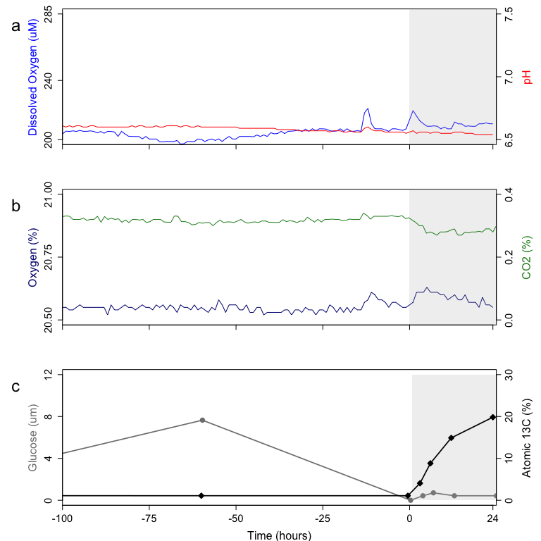

```r
setwd("/Users/oliviaahern/Documents/GitHub/SIP_CopyNumber")


{

# file contains info on MC2, Chemostat, measurements taken every 15 minutes
data=read.csv(file="datafiles/m2_do_02_edit.csv",header=T)
# subset to get the right time frame
data=data.frame(data)
data$T=as.numeric(data$T)
read=subset(data, T <= 24)
read=subset(read, T >= -100)

time=read$T
ph= read$pH.M2
do=read$DO.M2..uM.
heado=read$O2.M2....
heado2=read$CO2.M2....

  par(mar=c(4,7,1,5), mfrow=c(3,1),xpd=F)
  plot(time, do,type='l',col='blue',xlab=" ", ylab = "", xlim=c(-100,25), xaxt='n', xaxs = 'i',cex.axis=1.4, yaxt='n', ylim=c(200,285))
  axis(2, at=c(200,240,285),cex.axis=1.4)
  rect(xleft=0, xright=240, ybottom=111, ytop=300, col= rgb(0.7,0.7,0.7,alpha=0.2),
    border=NA)
  mtext(side=2,"Dissolved Oxygen (uM)", col = 'blue', padj=-3)
    axis(side=1, at=c(-100, -75, -50, -25, 0, 24),cex.axis=1.4,labels = FALSE)
  par(new = TRUE)
  plot(time, ph,col='red',type = "l", axes = FALSE, bty = "n", xlab = "", ylab = "",xlim=c(-100,25),xaxs = 'i',cex.axis=1.4, ylim=c(6.5,7.5))
  mtext(side=4, "pH", col ='red', line=3)
  axis(side=4, at = c(6.5, 7,7.5),cex.axis=1.4)
  mtext("a", adj=-.12,padj=-10,side=1,srt=-90,cex=1.5,font=1)
#  legend(25,7.4,legend=c("12C Glucose", "13C Glucose"), pch=22, pt.bg=c("white",'gray70'), bt='n')



  plot(time, heado,type='l',col='navy',xlab=" ", ylab = "", xlim=c(-100,25), xaxt='n', xaxs = 'i',cex.axis=1.4, yaxt='n', ylim=c(20.5,21))
  axis(2, at=c(20.5,20.75,21),cex.axis=1.4)
  rect(xleft=0, xright=240, ybottom=0, ytop=300, col= rgb(0.7,0.7,0.7,alpha=0.2),border=NA)
  mtext(side=2,"Oxygen (%)", col = 'navy', padj=-3)
    axis(side=1, at=c(-100, -75, -50, -25, 0, 24),cex.axis=1.4,labels = FALSE)
  par(new = TRUE)
  plot(time, heado2,col='forestgreen',type = "l", axes = FALSE, bty = "n", xlab = "", xlim=c(-100,24),ylab = "", xaxs = 'i',cex.axis=1.4, yaxt='n', ylim=c(0,0.4))
  mtext(side=4, "CO2 (%)", col ='forestgreen', line=3)
  axis(side=4, at = c(0,0.2,0.4),cex.axis=1.4)
  mtext("b", adj=-.12,padj=-10,side=1,srt=-90,cex=1.5,font=1)

# file contains info on MC2, Chemostat, data was taken daily
read=read.csv(file="datafiles/states_gluc.csv",header=T)
read=read[1:7,]
read=data.frame(read)
glucose=read$Glucose_um
time_glucose=read$Time

  # par(mar=c(5,41.5,1,5))
  plot(time_glucose,read$Glucose_um,type='o',ylim=c(0,12),xlab= " ",
       ylab = " ",col='gray50',bg='gray50',pch=21,cex.axis=1,cex.lab=1,cex=1.2,lwd=1.7, xlim=c(-100,24), xaxs = 'i',
       yaxt='n', xaxt='n',cex.axis=1.4) #xaxt=c(-144,0,48,120,240))
  rect(xleft=0, xright=24, ybottom=0, ytop=12, col= rgb(0.7,0.7,0.7,alpha=0.2),
    border=NA)
  mtext(side=2, "Glucose (um)", padj=-3, col="gray50")
  axis(side=2,at=c(0,4,8,12),cex.axis=1.4)
  par(new = TRUE)
  plot(time_glucose,read$Atom..13C,pch=23, lwd=1.7,
       bg='black',type = "o", axes = FALSE, bty = "n", xlab = "", ylab = "", ylim=c(0,30), cex=1.2,xlim=c(-100,25), xaxs = 'i',cex.axis=1.4)
  mtext(side=4, "Atomic 13C (%)", line=3)
  axis(side=4, at=c(0, 10,20,30),cex.axis=1.4)
    axis(side=1, at=c(-100, -75, -50, -25, 0, 24),cex.axis=1.4)

  mtext(side=1, "Time (hours)", line=3)
  #legend('topleft',legend=c("Glucose (uM)","Atomic 13C"), pch =c(21,23), pt.bg= c('gray70','black'), bty='n')
 # mtext("c", adj=-.15,padj=-9,side=1,srt=-90,cex=1.5,font=1)
    mtext("c", adj=-.12,padj=-10,side=1,srt=-90,cex=1.5,font=1)

}
```

## qPCR Buoyant Density Gradients

### Figure 2

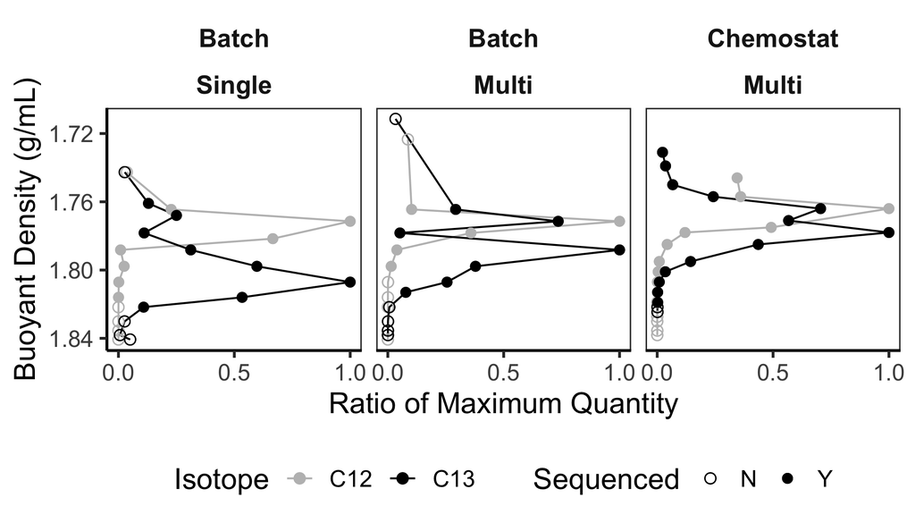

```r
data<-read.csv("datafiles/exp3_bd.csv",header=T,row.names=1)
qPCR_data=data.frame(data)

desired_order=c("Single", "Multi")
qPCR_data$Substrate <- factor(qPCR_data$Substrate, levels = desired_order)


library(ggpubr)
gplot1=ggplot(data=qPCR_data, aes(x=BD, y=R_MAX, col=Isotope))+
    geom_line() +
  geom_point(aes(shape=Sequenced),size=2.5) +
  theme_bw(base_size = 16) +
    facet_wrap(Culture ~ Substrate)  +
  coord_flip() +
  scale_color_manual(values=c("gray","black")) +
#   scale_fill_manual(values=c("white","black")) +
  xlab("Buoyant Density (g/mL)") +
  ylab("Ratio of Maximum Quantity") +
    scale_x_reverse(breaks=c(1.72,1.76,1.80, 1.84)) +
  # xlim(c(1.72, 1.841)) +
  scale_y_continuous(breaks = c(0, 0.5, 1)) +
   theme(axis.line = element_line(colour = "black"),
    panel.grid.major = element_blank(),
    strip.text = element_text(size = 14, face = "bold"),
    strip.background = element_blank(),
    panel.grid.minor = element_blank(),
    legend.position='bottom') +
  geom_point(aes(shape = Sequenced), size = 2.5) +
scale_shape_manual(values = c("N" = 1, "Y" = 16))
gplot1
```

```r
#ggsave('rmaxplot.svg', plot=gplot1, dpi=300, width=8,height=4)
```

# Import 16S Data

```r
numbs=read.csv(file='datafiles/copy_number.csv',
               header=T)
number=numbs$x
x<-read.csv(file='datafiles/asv-table.csv',
            header=TRUE,row.names=1)
x2=sweep(x, 1, number, "/") # divide asvs by 16S gene copy number
x2=ceiling(x2) # round it

OTU = otu_table(x2, taxa_are_rows=T)
taxa<-read.csv(file='datafiles/taxonomy.csv',
               header=TRUE,row.names=1)
t<-as.matrix(taxa)
tax2<-tax_table(t)
map<-import_qiime_sample_data("datafiles/sampling_batch_exp3_combined.txt")
tree=read.newick("datafiles/tree.nwk")
phyo1 = phyloseq(OTU, tax2,map,tree)
 # 1238 ASVs
phyo1 = subset_taxa(phyo1, !Order=="Chloroplast")
 #  1125, removed 113 that were chloroplasts
phyo1 = subset_taxa(phyo1, !Family=="Mitochondria")
 # 1104, removed 21 mitochondria
phyo1=subset_taxa(phyo1, !Phylum =="Cyanobacteria")
 # 1089, removed 15 cyanobacteria
phyo1=subset_taxa(phyo1, !Phylum =="")
 # 1078, removed 19 no assignment to phyla level

phyo_frac=subset_samples(phyo1, Isotope !="NA")
phyo_frac <- prune_samples(sample_sums(phyo_frac) > 0, phyo_frac)
```

# qSIP2

following this [workflow](https://jeffkimbrel.github.io/qSIP2/articles/qSIP_workflow.html#sample-data)

```r
# read in source data
comm2=read.csv(file='datafiles/comm_source_copyno.csv',header=T)
comm2=data.frame(comm2)
source=qsip_source_data(comm2, isotope="isotope", source_mat_id = 'source', isotopolog = 'isotopolog', timepoint='timepoint')

# read in sample data
df <- get_dataframe(source, original_headers = TRUE)

#frac=read.csv('frac_qpcr.csv',header=TRUE)
#frac$volume <- comm2$volume_filtered[match(frac$source, comm2$source)]
#write.csv(frac,'frac_qpcr_edit.csv')
read=read.csv(file='datafiles/sample_data_qsip2.csv',header=T)
samples=data.frame(read)
sample_df <- samples %>%
  add_gradient_pos_rel_amt(source_mat_id = "source", amt = "rna_conc")

sample_object<- qsip_sample_data(sample_df,
  sample_id = "asv_id",
  source_mat_id = "source",
  gradient_position = "Fraction",
  gradient_pos_density = "density_g_ml",
  gradient_pos_amt = "rna_conc",
  gradient_pos_rel_amt = "gradient_pos_rel_amt"
)
# ps_filt <- prune_taxa(taxa_sums(phyo) > 2, phyo)
# table1=otu_table(ps_filt)
# table=data.frame(table1)
# write.csv(table, 'asv_tab_qsip2.csv')
library(dplyr)
library(qSIP2)
asv_table=read.csv('datafiles/asv-table.csv',header=T)
feature_object <- qsip_feature_data(asv_table,
  feature_id = "X.OTU.ID", type='counts'
)



feature_df <- get_dataframe(feature_object)

feature_df_filt <- feature_df %>%
  mutate(across(-feature_id, ~ .x * (.x >= 5))) %>%
  filter(rowSums(across(-feature_id)) > 0)
feature_object_filt <- qsip_feature_data(feature_df_filt, type = "counts")

qsip_object <- qsip_data(
  source_data = source,
  sample_data = sample_object,
  feature_data = feature_object_filt
)
```

```
## ✔ There are 6 source_mat_ids, and they are all shared between the source and sample objects.
```

```
## ! feature_data has 9 sample_id(s) that are missing from the sample_data.
```

```
## ! Missing source_mat_ids/sample_ids have not been removed from the dataset.
```

```
## ! Run `get_unshared_ids()` on your <qsip_data> object to show IDs missing from datasets.
```

### plot the weighted average densities

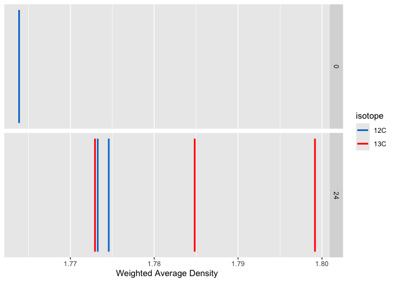

```r
plot_source_wads(qsip_object,
                 group = "timepoint")
```

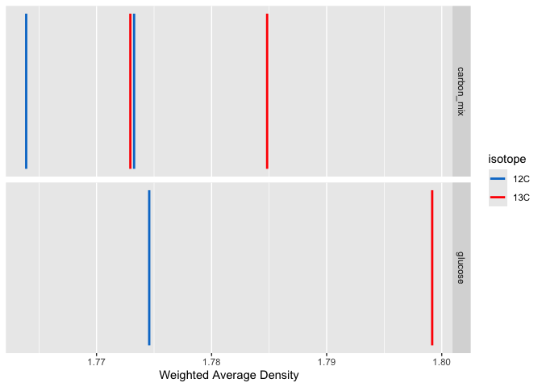

```r
plot_source_wads(qsip_object,
                 group = "isotopolog")
```

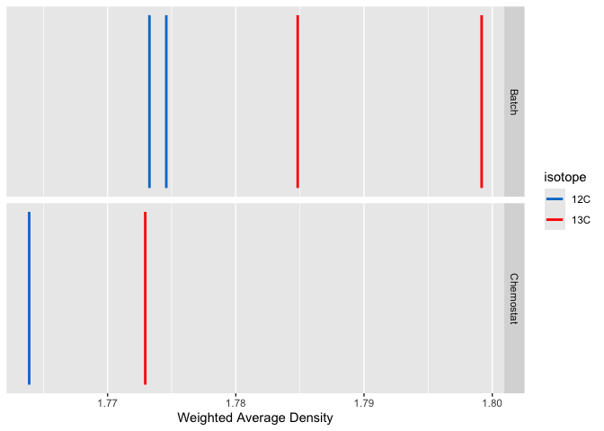

```r
plot_source_wads(qsip_object,
                 group = "B_C")
```

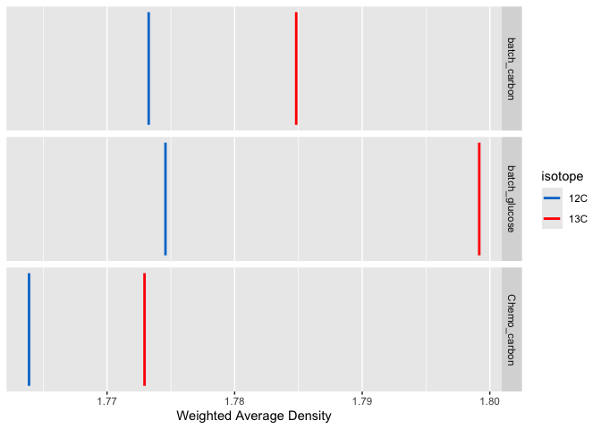

```r
plot_source_wads(qsip_object,
                 group = "treatment")
```

### plot curves

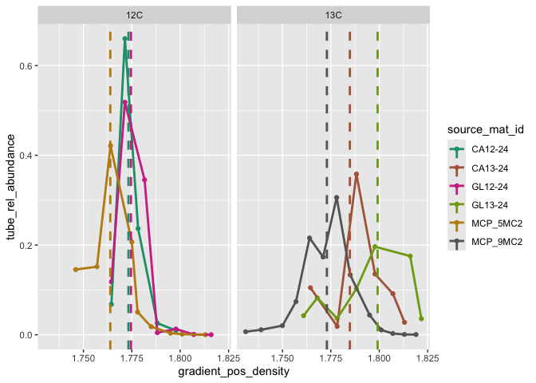

```r
plot_sample_curves(qsip_object,
                   facet_by = "isotope",
                   show_wad = TRUE)
```

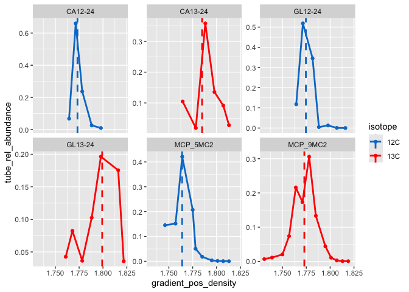

```r
plot_sample_curves(qsip_object,
                   facet_by = "source",
                   show_wad = TRUE)
```

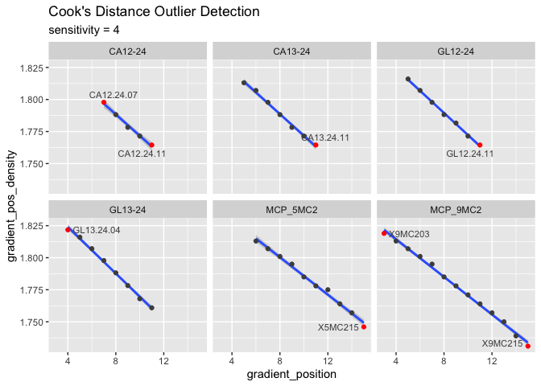

```r
plot_density_outliers(qsip_object)
```

### run analysis

```r
feature_df <- get_dataframe(feature_object) |>
  dplyr::filter(dplyr::if_any(-feature_id, ~ .x >= 5))

qsip_obj5 <- qsip_data(
  source_data  = source,
  sample_data  = sample_object,
  feature_data = qsip_feature_data(feature_df, type = "counts")
)
```

```
## ✔ There are 6 source_mat_ids, and they are all shared between the source and sample objects.
```

```
## ! feature_data has 9 sample_id(s) that are missing from the sample_data.
```

```
## ! Missing source_mat_ids/sample_ids have not been removed from the dataset.
```

```
## ! Run `get_unshared_ids()` on your <qsip_data> object to show IDs missing from datasets.
```

```r
pairs <- get_comparison_groups(qsip_obj5,
                               group = "treatment",
                               isotope = "isotope",
                               source_mat_id = "source_mat_id") |>
  dplyr::transmute(treatment, unlabeled = `12C`, labeled = `13C`)
```

#### find where the mark is between the light and heavy band

in order to see if there is differences in the number of 16S copies of enriched taxa, we first find out where the light and heavy deviates in our runs. This script finds where 95 % of the light RNA falls in the gradient. The output is where that 95% line is (on the figure) and the percent of RNA remaining in the gradient that is not in the 95%.

```r
library(dplyr)
library(ggplot2)

# rename levels in the buoyant density files
lvl <- c("single-substrate batch", "multi-substrate batch", "multi-substrate chemostat")
## read in the data for each substrate
bd <- read.csv("datafiles/exp3_bd.csv") %>%
  mutate(
    isotope   = ifelse(Isotope == "C12", "12C", "13C"),
    gradient  = paste(Culture, Substrate, Isotope, sep = "_"),
    treatment = paste0(tolower(Substrate), "-substrate ", tolower(Culture)),
    treatment = factor(treatment, levels = c(lvl, setdiff(unique(treatment), lvl))),
    sequenced = Sequenced == "Y"
  ) %>%
  filter(!is.na(Conc), !is.na(BD)) %>%
  arrange(gradient, BD) %>%
  group_by(gradient) %>%
  mutate(rel_amt   = Conc / sum(Conc),
                ratio_max = Conc / max(Conc)) %>%
  ungroup()

count(bd, treatment, isotope, sequenced)
```

```
## # A tibble: 12 × 4
##    treatment                 isotope sequenced     n
##    <fct>                     <chr>   <lgl>     <int>
##  1 single-substrate batch    12C     FALSE         5
##  2 single-substrate batch    12C     TRUE          7
##  3 single-substrate batch    13C     FALSE         4
##  4 single-substrate batch    13C     TRUE          8
##  5 multi-substrate batch     12C     FALSE         7
##  6 multi-substrate batch     12C     TRUE          5
##  7 multi-substrate batch     13C     FALSE         5
##  8 multi-substrate batch     13C     TRUE          7
##  9 multi-substrate chemostat 12C     FALSE         5
## 10 multi-substrate chemostat 12C     TRUE         10
## 11 multi-substrate chemostat 13C     FALSE         2
## 12 multi-substrate chemostat 13C     TRUE         13
```

```r
# For each 12C treatment, find the point in which 95% of the RNA lies in the light. This is the cutoff for the heavy/light bands for which we will calculate the differences in number of 16S copies from the light to dark
cutoffs <- bd %>%
  filter(isotope == "12C") %>%
  group_by(treatment) %>%
  mutate(lighter_cum = cumsum(rel_amt) - rel_amt) %>%
  summarize(
    heavy_cutoff  = (max(BD[lighter_cum < 0.95]) + min(BD[lighter_cum >= 0.95])) / 2,
    pct_12C_heavy = 100 * sum(rel_amt[lighter_cum >= 0.95]),
    .groups = "drop"
  )

cutoffs
```

```
## # A tibble: 3 × 3
##   treatment                 heavy_cutoff pct_12C_heavy
##   <fct>                            <dbl>         <dbl>
## 1 single-substrate batch            1.78          1.83
## 2 multi-substrate batch             1.78          3.46
## 3 multi-substrate chemostat         1.78          2.46
```

```r
cutoffs %>%
  dplyr::mutate(heavy_cutoff = round(heavy_cutoff, 4)) %>%
  as.data.frame()
```

```
##                   treatment heavy_cutoff pct_12C_heavy
## 1    single-substrate batch       1.7849      1.825470
## 2     multi-substrate batch       1.7832      3.457845
## 3 multi-substrate chemostat       1.7815      2.464054
```

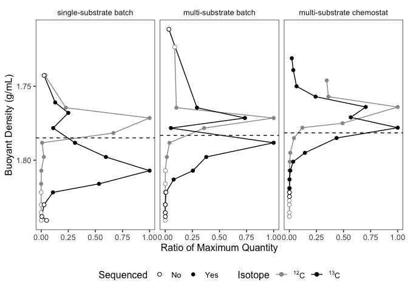

```r
# plotting
ggplot(bd, aes(x = ratio_max, y = BD, colour = isotope, group = gradient)) +
  geom_path() +
  geom_point(aes(shape = sequenced), size = 2, fill = "white") +
  geom_hline(data = cutoffs, aes(yintercept = heavy_cutoff), linetype = "dashed") +
  scale_y_reverse() +
  scale_colour_manual(values = c("12C" = "grey60", "13C" = "black"),
                      labels = c(expression({}^12*C), expression({}^13*C))) +
  scale_shape_manual(values = c("FALSE" = 21, "TRUE" = 16),
                     labels = c("FALSE" = "No", "TRUE" = "Yes")) +
  facet_wrap(~ treatment) +
  labs(x = "Ratio of Maximum Quantity", y = "Buoyant Density (g/mL)",
       colour = "Isotope", shape = "Sequenced") +
  theme_bw(base_size = 12) +
  theme(panel.grid = element_blank(), strip.background = element_blank(),
        legend.position = "bottom")
```

#### find fractionation noise threshold

Following the protocol from this paper [Sieradzki et al 2020](https://doi.org/10.1128/msystems.00151-20), we are going to find the variability of taxon density shifts in teh 12C. This is the tube to to tube or fractionation variability. So how much an ASV differs in their 12C distribution from one tube to another. This is measured as the median of 2 times the standard deviation of the unlabelled weighted average density (WAD). so this script:

1. finds the top 100 ASVs in your 12C gradients
2. finds shared ASVs in teh top 100 (in my case 87)
3. calculates the differences in the 12C peaks of those ASVs between the different gradients

```r
library(dplyr)
library(magrittr)
# get the sequenced 12C fractions
samp_wad <- get_dataframe(sample_object) %>%
  dplyr::select(sample_id, source_mat_id, gradient_pos_density, gradient_pos_rel_amt) %>%
  dplyr::filter(source_mat_id %in% pairs$unlabeled)

# get the ASVs and put them in long formate
feat_long <- feature_df %>%
  tidyr::pivot_longer(-feature_id, names_to = "sample_id", values_to = "count") %>%
  dplyr::inner_join(samp_wad, by = "sample_id") %>%
  dplyr::group_by(sample_id) %>%
  dplyr::mutate(tube_rel = if (sum(count) > 0) count / sum(count) * gradient_pos_rel_amt else 0) %>%
  dplyr::ungroup()
# only look at the batch tubes
feat_long=subset(feat_long, source_mat_id !="MCP_5MC2" )

# find the top 100
top100 <- feat_long %>%
  dplyr::group_by(feature_id) %>%
  dplyr::summarize(total = sum(count), .groups = "drop") %>%
  dplyr::slice_max(total, n = 100) %>%
  dplyr::pull(feature_id)
# find the shared ASVs in the top 100 (87) and then calculate 2 times the standard deviation of the WAD
sd_per_asv <- feat_long %>%
  dplyr::filter(feature_id %in% top100) %>%
  dplyr::group_by(feature_id, source_mat_id) %>%
  dplyr::summarize(WAD = sum(gradient_pos_density * tube_rel) / sum(tube_rel),
                   .groups = "drop") %>%
  dplyr::filter(is.finite(WAD)) %>%
  dplyr::group_by(feature_id) %>%
  dplyr::filter(dplyr::n() >= 2) %>%
  dplyr::summarize(sd2 = 2 * sd(WAD), .groups = "drop")
```

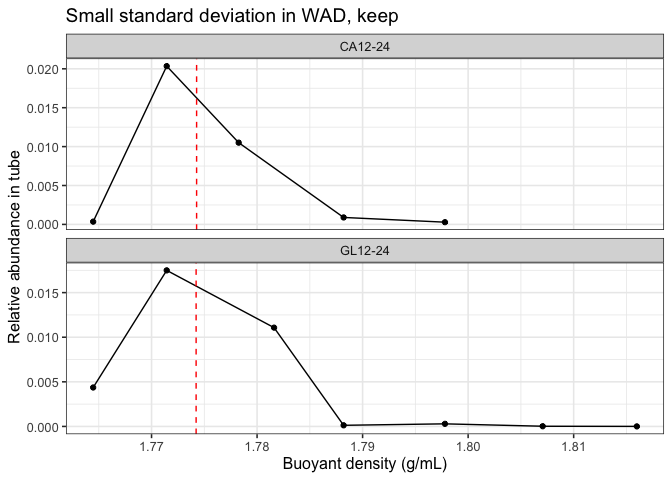

```r
## lets double check this worked
sd_sort <- sd_per_asv %>%
    arrange(sd2)

example_asv1=sd_sort$feature_id[1]
example_asv2=sd_sort$feature_id[87]

ex_dist <- feat_long %>%
  filter(feature_id == example_asv1)
ex_wad <- ex_dist |>
  dplyr::group_by(source_mat_id) |>
  dplyr::summarize(WAD = sum(gradient_pos_density * tube_rel) / sum(tube_rel),
                   .groups = "drop")
ggplot(ex_dist, aes(x = gradient_pos_density, y = tube_rel)) +
  geom_line() +
  geom_point() +
  geom_vline(data = ex_wad, aes(xintercept = WAD), linetype = "dashed", colour = "red") +
  facet_wrap(~ source_mat_id, ncol = 1, scales = "free_y") +
  labs(title = "Small standard deviation in WAD, keep",
       x = "Buoyant density (g/mL)",
       y = "Relative abundance in tube") +
  theme_bw(base_size = 12)
```

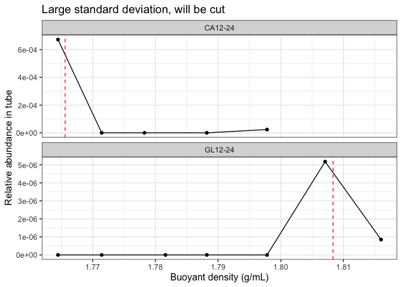

```r
ex_dist <- feat_long %>%
  filter(feature_id == example_asv2)
ex_wad <- ex_dist |>
  dplyr::group_by(source_mat_id) |>
  dplyr::summarize(WAD = sum(gradient_pos_density * tube_rel) / sum(tube_rel),
                   .groups = "drop")
ggplot(ex_dist, aes(x = gradient_pos_density, y = tube_rel)) +
  geom_line() +
  geom_point() +
  geom_vline(data = ex_wad, aes(xintercept = WAD), linetype = "dashed", colour = "red") +
  facet_wrap(~ source_mat_id, ncol = 1, scales = "free_y") +
  labs(title = "Large standard deviation, will be cut",
       x = "Buoyant density (g/mL)",
       y = "Relative abundance in tube") +
  theme_bw(base_size = 12)
```

```r
shift_threshold <- median(sd_per_asv$sd2, na.rm = TRUE)

shift_threshold    # g/mL
```

```
## [1] 0.002877644
```

```r
nrow(sd_per_asv)   # ASVs contributing to the threshold
```

```
## [1] 87
```

#### run qSIP2

must be in at least 3 fractions from labelled and unlaebelled

```r
batch_unlab <- c("CA12-24", "GL12-24")

unlab_list <- lapply(pairs$treatment, function(trt) {
  if (grepl("^batch", trt)) batch_unlab else pairs$unlabeled[pairs$treatment == trt]
})

qsip_by_trt <- lapply(seq_len(nrow(pairs)), function(i) {
  run_feature_filter(qsip_obj5,
    unlabeled_source_mat_ids = unlab_list[[i]],
    labeled_source_mat_ids   = pairs$labeled[i],
    min_unlabeled_sources    = 1,
    min_labeled_sources      = 1,
    min_unlabeled_fractions  = 3,
    min_labeled_fractions    = 3,
    group = pairs$treatment[i],
    quiet = TRUE
  ) |>
    run_resampling(resamples = 1000, with_seed = 17, allow_failures = TRUE,
                   progress = FALSE, quiet = TRUE) %>%
    run_EAF_calculations()
})
names(qsip_by_trt) <- pairs$treatment

# get EAF
eaf <- summarize_EAF_values(qsip_by_trt, confidence = 0.95) %>%
  dplyr::select(treatment = group, feature_id, observed_EAF, lower, upper, pval,
                unlabeled_sources)
```

```
## ℹ Confidence level = 0.95
```

```r
eaf
```

```
## # A tibble: 224 × 7
##    treatment   feature_id observed_EAF    lower    upper  pval unlabeled_sources
##    <chr>       <chr>             <dbl>    <dbl>    <dbl> <dbl>             <int>
##  1 Chemo_carb… 00feb6926…    -0.0439   -4.39e-2 -4.39e-2     0                 1
##  2 Chemo_carb… 02dd75f97…    -0.000546 -5.46e-4 -5.46e-4     0                 1
##  3 Chemo_carb… 07eb166d0…     0.0477    4.77e-2  4.77e-2     0                 1
##  4 Chemo_carb… 0893f5bbb…    -0.479    -4.79e-1 -4.79e-1     0                 1
##  5 Chemo_carb… 0ae5531a9…     0.0555    5.55e-2  5.55e-2     0                 1
##  6 Chemo_carb… 101ab1c0c…     0.0551    5.51e-2  5.51e-2     0                 1
##  7 Chemo_carb… 1083eb67a…     0.0411    4.11e-2  4.11e-2     0                 1
##  8 Chemo_carb… 137dc661f…     0.0448    4.48e-2  4.48e-2     0                 1
##  9 Chemo_carb… 1583d8af9…     0.0864    8.64e-2  8.64e-2     0                 1
## 10 Chemo_carb… 1c2b8892a…     0.228     2.28e-1  2.28e-1     0                 1
## # ℹ 214 more rows
```

```r
range(eaf$lower)
```

```
## [1] -1.0303840  0.7286195
```

```r
range(eaf$upper)
```

```
## [1] -1.0303840  0.8904448
```

```r
eaf_df <- summarize_EAF_values(qsip_by_trt, confidence = 0.95) %>%
  dplyr::select(treatment = group, feature_id, observed_EAF, lower, upper, pval,
                unlabeled_sources)
```

```
## ℹ Confidence level = 0.95
```

##### calculate the number of 16S copies enriched per treatmetn

```r
std_length_nt <- 465   # length (nt) of the RNA standard used for the qPCR curve
frac_vol_ml   <- 1     # fraction volume in mL (1 = copies per mL)
avogadro      <- 6.02214076e23

## calculate the shift between heavy and light for each ASV
shift_df <- lapply(names(qsip_by_trt), function(trt) {
  get_EAF_data(qsip_by_trt[[trt]]) %>%
    dplyr::filter(observed == TRUE) %>%
    dplyr::transmute(treatment = trt, feature_id,
                     W_unlab = W_unlab_mean, W_lab = W_lab_mean,
                     shift = W_lab_mean - W_unlab_mean)
}) %>%
  dplyr::bind_rows()

# calculate the number of 16S copies per fraction
bd <- read.csv("datafiles/exp3_bd.csv") %>%
  dplyr::mutate(copies = Conc * 1e-9 * avogadro / (std_length_nt * 320.5 + 159) * frac_vol_ml) %>%
  dplyr::select(seq_id, copies)
# get sample ids
samp <- get_dataframe(sample_object) %>%
  dplyr::select(sample_id, source_mat_id) %>%
  dplyr::inner_join(dplyr::select(pairs, treatment, source_mat_id = labeled),
                    by = "source_mat_id")



# 1) calcualtes number of asvs copies per fraciton,
# 2) sum those to get total_copies,
# 3) get eaf estimates and confidence intervals (upper and lower) and WAD shift
# 4) sees if an ASV is enriched if it is greater than the tube variability (0.002877644 g/mL)
asv_shift <- feature_df %>%
  tidyr::pivot_longer(-feature_id, names_to = "sample_id", values_to = "count") %>%
  dplyr::inner_join(samp, by = "sample_id") %>%
  dplyr::inner_join(bd, by = c("sample_id" = "seq_id")) %>%
  dplyr::group_by(sample_id) %>%
  dplyr::mutate(asv_copies = if (sum(count) > 0) count / sum(count) * copies else 0) %>%
  dplyr::ungroup() %>%
  dplyr::group_by(treatment, feature_id) %>%
  dplyr::summarize(total_copies = sum(asv_copies), .groups = "drop") %>%
  dplyr::inner_join(eaf_df,   by = c("treatment", "feature_id")) %>%
  dplyr::inner_join(shift_df, by = c("treatment", "feature_id")) %>%
  dplyr::mutate(
    enriched        = shift > shift_threshold,
    enriched_copies = ifelse(enriched, total_copies, 0)
  ) %>%
  dplyr::select(treatment, feature_id, W_unlab, W_lab, shift, observed_EAF,
                lower, upper, pval, enriched, total_copies, enriched_copies) %>%
  dplyr::arrange(treatment, dplyr::desc(shift))

asv_shift
```

```
## # A tibble: 224 × 12
##    treatment    feature_id  W_unlab W_lab   shift observed_EAF lower upper  pval
##    <chr>        <chr>         <dbl> <dbl>   <dbl>        <dbl> <dbl> <dbl> <dbl>
##  1 Chemo_carbon ffd660f96b…    1.75  1.76 0.0156         0.290 0.290 0.290     0
##  2 Chemo_carbon efbe1f58b1…    1.76  1.78 0.0153         0.285 0.285 0.285     0
##  3 Chemo_carbon 285bfcf58e…    1.76  1.77 0.0146         0.273 0.273 0.273     0
##  4 Chemo_carbon 936f76885e…    1.75  1.76 0.0137         0.255 0.255 0.255     0
##  5 Chemo_carbon 1c2b8892a0…    1.76  1.77 0.0122         0.228 0.228 0.228     0
##  6 Chemo_carbon 3fa2974b1f…    1.76  1.78 0.0118         0.220 0.220 0.220     0
##  7 Chemo_carbon 5ed8f8f3a9…    1.76  1.77 0.0103         0.192 0.192 0.192     0
##  8 Chemo_carbon 21bdb6c8cb…    1.75  1.76 0.0102         0.189 0.189 0.189     0
##  9 Chemo_carbon d2af52fc6f…    1.77  1.78 0.00982        0.183 0.183 0.183     0
## 10 Chemo_carbon 3e5cc40066…    1.76  1.77 0.00974        0.182 0.182 0.182     0
## # ℹ 214 more rows
## # ℹ 3 more variables: enriched <lgl>, total_copies <dbl>, enriched_copies <dbl>
```

```r
asv_shift %>%
  dplyr::group_by(treatment) %>%
  dplyr::summarize(
    n_asvs              = dplyr::n(),
    n_enriched          = sum(enriched),
    enriched_copies     = sum(enriched_copies),
    total_copies        = sum(total_copies),
    pct_enriched_copies = 100 * enriched_copies / total_copies,
    .groups = "drop"
  )
```

```
## # A tibble: 3 × 6
##   treatment   n_asvs n_enriched enriched_copies total_copies pct_enriched_copies
##   <chr>        <int>      <int>           <dbl>        <dbl>               <dbl>
## 1 Chemo_carb…     63         32   266316047016.      2.85e11                93.6
## 2 batch_carb…     70         58     4467837438.      4.76e 9                93.9
## 3 batch_gluc…     91         66    14179387576.      1.53e10                92.5
```

note taxa are considered enriched if the shift is greater than the variation between tubes (shift > shift_threshold)

This shows the cutoff due ot variation that were killed

```r
eaf_per_shift=subset(asv_shift, enriched=="TRUE")
eaf_per_shift %>%
  dplyr::group_by(treatment) %>%
   dplyr::summarize(min_EAF = min(observed_EAF))
```

```
## # A tibble: 3 × 2
##   treatment     min_EAF
##   <chr>           <dbl>
## 1 Chemo_carbon   0.0551
## 2 batch_carbon   0.0679
## 3 batch_glucose  0.0642
```

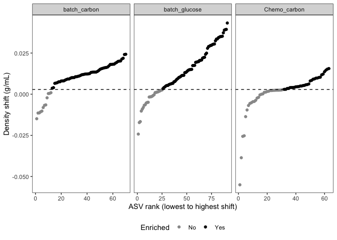

```r
asv_shift %>%
  dplyr::group_by(treatment) %>%
  dplyr::arrange(shift, .by_group = TRUE) %>%
  dplyr::mutate(rank = dplyr::row_number()) %>%
  dplyr::ungroup() %>%
  ggplot(aes(x = rank, y = shift, colour = enriched)) +
  geom_point(size = 1.5) +
  geom_hline(yintercept = shift_threshold, linetype = "dashed") +
  scale_colour_manual(values = c("FALSE" = "grey60", "TRUE" = "black"),
                      labels = c("FALSE" = "No", "TRUE" = "Yes")) +
  facet_wrap(~ treatment, scales = "free_x") +
  labs(x = "ASV rank (lowest to highest shift)", y = "Density shift (g/mL)",
       colour = "Enriched") +
  theme_bw() +
  theme(panel.grid = element_blank(),
        legend.position = "bottom")
```

```r
asv_shift %>%
  dplyr::group_by(treatment) %>%
  dplyr::summarize(n_called_by_qSIP   = dplyr::n(),
                   n_WAD_too_small = sum(!enriched),
                   n_kept    = sum(enriched),
                   pct_kept    = n_kept/n_called_by_qSIP)
```

```
## # A tibble: 3 × 5
##   treatment     n_called_by_qSIP n_WAD_too_small n_kept pct_kept
##   <chr>                    <int>           <int>  <int>    <dbl>
## 1 Chemo_carbon                63              31     32    0.508
## 2 batch_carbon                70              12     58    0.829
## 3 batch_glucose               91              25     66    0.725
```

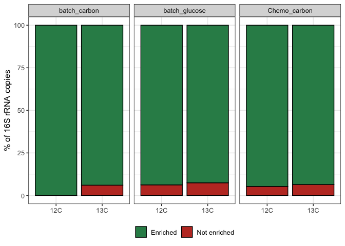

```r
pair_12C <- data.frame(treatment     = c("batch_carbon", "batch_glucose", "Chemo_carbon"),
                       source_mat_id = c("CA12-24", "GL12-24", "MCP_5MC2"))

copies_12C <- feature_df %>%
  tidyr::pivot_longer(-feature_id, names_to = "sample_id", values_to = "count") %>%
  dplyr::inner_join(get_dataframe(sample_object) %>%
                      dplyr::select(sample_id, source_mat_id) %>%
                      dplyr::inner_join(pair_12C, by = "source_mat_id"),
                    by = "sample_id") %>%
  dplyr::inner_join(bd, by = c("sample_id" = "seq_id")) %>%
  dplyr::group_by(sample_id) %>%
  dplyr::mutate(asv_copies = count / sum(count) * copies) %>%
  dplyr::group_by(treatment, feature_id) %>%
  dplyr::summarize(copies_12C = sum(asv_copies), .groups = "drop")

copies_bar <- asv_shift %>%
  dplyr::left_join(copies_12C, by = c("treatment", "feature_id")) %>%
  tidyr::pivot_longer(c(copies_12C, total_copies), names_to = "isotope", values_to = "copies") %>%
  dplyr::mutate(isotope = ifelse(isotope == "copies_12C", "12C", "13C")) %>%
  dplyr::group_by(treatment, isotope, enriched) %>%
  dplyr::summarize(copies = sum(copies, na.rm = TRUE), .groups = "drop") %>%
  dplyr::group_by(treatment, isotope) %>%
  dplyr::mutate(pct = 100 * copies / sum(copies)) %>%
  dplyr::ungroup() %>%
  dplyr::mutate(status = ifelse(enriched, "Enriched", "Not enriched"))

ggplot(copies_bar, aes(x = isotope, y = pct, fill = status)) +
  geom_col(colour = "black") +
  scale_fill_manual(values = c("Enriched" = "#2E8B57", "Not enriched" = "#C0392B")) +
  facet_wrap(~ treatment) +
  labs(x = NULL, y = "% of 16S rRNA copies", fill = NULL) +
  theme_bw(base_size = 12) +
  theme(legend.position = "bottom")
```

##### remove outlier ASVs (12C vs 13C abundance mismatch)

Because each treatment has a single 12C and a single 13C gradient started from the same inoculum, an ASV should make up a similar share of total 16S rRNA copies in both tubes. ASVs whose share differs more than 10-fold between the paired gradients are usually present at trace levels in one tube, so their WAD rests on a few reads and the density shift is unreliable. We excluded these ASVs.

```r
# ---- tube totals ----
tot_12C <- copies_12C %>%
  dplyr::group_by(treatment) %>%
  dplyr::summarize(tot_12C = sum(copies_12C))

tot_13C <- samp %>%
  dplyr::inner_join(bd, by = c("sample_id" = "seq_id")) %>%
  dplyr::group_by(treatment) %>%
  dplyr::summarize(tot_13C = sum(copies))

# ---- remove >10-fold mismatches ----
check <- asv_shift %>%
  dplyr::left_join(copies_12C, by = c("treatment", "feature_id")) %>%
  dplyr::left_join(tot_12C, by = "treatment") %>%
  dplyr::left_join(tot_13C, by = "treatment") %>%
  dplyr::mutate(fold_diff = pmax(total_copies / tot_13C, copies_12C / tot_12C) /
                            pmin(total_copies / tot_13C, copies_12C / tot_12C))

sum(check$fold_diff > 10)   # ASVs excluded
```

```
## [1] 18
```

```r
asv_final <- check %>%
  dplyr::filter(fold_diff <= 10)

# ---- final summary per treatment ----
final_summary <- asv_final |>
  dplyr::group_by(treatment) |>
  dplyr::summarize(
    n_asvs              = dplyr::n(),
    n_enriched          = sum(enriched),
    pct_enriched_copies = 100 * sum(enriched_copies) / sum(total_copies),
    .groups = "drop"
  )

print(final_summary)
```

```
## # A tibble: 3 × 4
##   treatment     n_asvs n_enriched pct_enriched_copies
##   <chr>          <int>      <int>               <dbl>
## 1 Chemo_carbon      59         31                93.6
## 2 batch_carbon      58         57                99.9
## 3 batch_glucose     89         66                92.7
```

```r
asv_results <- asv_final |>
  dplyr::select(treatment, feature_id, shift, observed_EAF, lower, upper, pval,
                enriched, total_copies, enriched_copies) |>
  dplyr::arrange(treatment, dplyr::desc(observed_EAF))

asv_enriched <- asv_results |>
  dplyr::filter(enriched)

asv_final_res=asv_enriched
```

## EAF vs 16S copy number

```r
# filter ASV EAF results
asv_results_filt=subset(asv_enriched, enriched=="TRUE")
asv_results_filt$Strain=asv_results_filt$feature_id
summary(as.factor(asv_results_filt$treatment))
```

```
##  batch_carbon batch_glucose  Chemo_carbon
##            57            66            31
```

```r
taxa=tax_table(phyo1)
asv_results_filt_tax=merge(asv_results_filt, taxa, by="Strain")

# get copy nmber info
numbs=read.csv(file='datafiles/copy_number.csv',
               header=T)
number=data.frame(cbind(numbs$label, numbs$x))
colnames(number)=c("Strain", "Copy_Number")

# glucose A values
glucose_phyo=subset_samples(phyo1, Treatment=="Single" & Culture =="Batch")
```

[output not shown]

```
## Also defined by 'tidytree'
```

[output not shown]

```
## Also defined by 'tidytree'
```

[output not shown]

```
## Also defined by 'tidytree'
```

[output not shown]

```
## Also defined by 'tidytree'
```

```r
glucose_phyo <- filter_taxa(glucose_phyo, function(x) any(x > 0), prune = TRUE)
```

```
## Found more than one class "phylo" in cache; using the first, from namespace 'phyloseq'
## Also defined by 'tidytree'
```

```r
tax_glucose=tax_table(glucose_phyo)
glucose_numb=merge(tax_glucose, number, by='Strain')
asv_results_filt_glu=subset(asv_results_filt, treatment=="batch_glucose")
glucose_A=merge(asv_results_filt_glu, glucose_numb, by="Strain")
dim(glucose_A)
```

```
## [1] 63 19
```

```r
head(asv_enriched)
```

```
## # A tibble: 6 × 10
##   treatment    feature_id          shift observed_EAF lower upper  pval enriched
##   <chr>        <chr>               <dbl>        <dbl> <dbl> <dbl> <dbl> <lgl>
## 1 Chemo_carbon ffd660f96ba6668b2… 0.0156        0.290 0.290 0.290     0 TRUE
## 2 Chemo_carbon efbe1f58b1e2984dd… 0.0153        0.285 0.285 0.285     0 TRUE
## 3 Chemo_carbon 285bfcf58e6f5f266… 0.0146        0.273 0.273 0.273     0 TRUE
## 4 Chemo_carbon 1c2b8892a0d7f828d… 0.0122        0.228 0.228 0.228     0 TRUE
## 5 Chemo_carbon 3fa2974b1f7010927… 0.0118        0.220 0.220 0.220     0 TRUE
## 6 Chemo_carbon 5ed8f8f3a98e669d8… 0.0103        0.192 0.192 0.192     0 TRUE
## # ℹ 2 more variables: total_copies <dbl>, enriched_copies <dbl>
```

```r
dim(subset(asv_enriched, treatment=="batch_glucose"))
```

```
## [1] 66 10
```

```r
# five carbon_batch
five_batch_phyo=subset_samples(phyo1, Treatment=="Multi" & Culture=="Batch")
```

```
## Found more than one class "phylo" in cache; using the first, from namespace 'phyloseq'
## Also defined by 'tidytree'
```

[output not shown]

```
## Also defined by 'tidytree'
```

[output not shown]

```
## Also defined by 'tidytree'
```

[output not shown]

```
## Also defined by 'tidytree'
```

```r
five_batch_phyo <- filter_taxa(five_batch_phyo, function(x) any(x > 0), prune = TRUE)
```

```
## Found more than one class "phylo" in cache; using the first, from namespace 'phyloseq'
## Also defined by 'tidytree'
```

```r
five_batch_tax=tax_table(five_batch_phyo)
five_batch_numb=merge(five_batch_tax, number, by="Strain")
asv_results_filt_batch_carb=subset(asv_results_filt, treatment=="batch_carbon")
five_batch_A=merge(asv_results_filt_batch_carb, five_batch_numb, by="Strain")
dim(five_batch_A)
```

```
## [1] 51 19
```

```r
# five carbon_chemo
five_chemo_phyo=subset_samples(phyo1, Treatment=="Multi" & Culture=="Chemostat")
```

```
## Found more than one class "phylo" in cache; using the first, from namespace 'phyloseq'
## Also defined by 'tidytree'
```

[output not shown]

```
## Also defined by 'tidytree'
```

[output not shown]

```
## Also defined by 'tidytree'
```

[output not shown]

```
## Also defined by 'tidytree'
```

```r
five_chemo_phyo <- filter_taxa(five_chemo_phyo, function(x) any(x > 0), prune = TRUE)
```

```
## Found more than one class "phylo" in cache; using the first, from namespace 'phyloseq'
## Also defined by 'tidytree'
```

```r
five_chemo_tax=tax_table(five_chemo_phyo)
five_chemo_numb=merge(five_chemo_tax, number, by="Strain")
asv_results_filt_chemo_carb=subset(asv_results_filt, treatment=="Chemo_carbon")
five_chemo_A=merge(asv_results_filt_chemo_carb, five_chemo_numb, by="Strain")

dim(five_chemo_A)
```

```
## [1] 30 19
```

```r
dim(five_batch_A)
```

```
## [1] 51 19
```

```r
dim(glucose_A)
```

```
## [1] 63 19
```

```r
# note that these ASVs were dropped because of theri taxonomy:
# dropped <- c("33036d95db3cb15dfa681dbd231b7213", "4d699b85fb27ee71fc6383ed36e50120",
          #   "a9360c0a1300c954aefbdaeb9109d345", #"5afc2a9c279a0e72cb96fb88e116f994",
  #           "687e1d94d2bfc46843a21e7706df067e", #"088bc2e5228101932e94ad30c2f7b3ec",
      #       "cbc0cbfe40912ff3227e87e167bb6113")
# they were either cyanobacteria or mitochondria
```

## Figure 3

```r
library(dplyr)

incorp_only <- bind_rows(
  glucose_A    |> mutate(Culture = "batch",     Substrate = "single"),
  five_batch_A |> mutate(Culture = "batch",     Substrate = "multi"),
  five_chemo_A |> mutate(Culture = "chemostat", Substrate = "multi")
) |>
  mutate(copy_number = as.numeric(as.character(Copy_Number)),
                A           = observed_EAF,
                Culture     = factor(Culture,   levels = c("batch", "chemostat")),
                Substrate   = factor(Substrate, levels = c("single", "multi"))) |>
  filter(!is.na(copy_number))
summary(as.factor(incorp_only$treatment))
```

```
##  batch_carbon batch_glucose  Chemo_carbon
##            51            63            30
```

```r
count(incorp_only, Culture, Substrate)   # chemostat should be here
```

```
##     Culture Substrate  n
## 1     batch    single 63
## 2     batch     multi 51
## 3 chemostat     multi 30
```

```r
custom_colors_class=c("Acidimicrobiia" ="#f21277",
                      "Actinobacteria" ="#a02016",
                      "Alphaproteobacteria" ="#ffb659",
                      "Bacteroidia" = "#48591c",
                      "Other" = 'gray',
                      "Deltaproteobacteria" ="#01a34a",
                      "Gammaproteobacteria" ="#7bc6ff",
                      "Planctomycetacia" ="#00539e",
                      "Verrucomicrobiae" ="#6868f2")

incorp_only$Class_ag = ifelse(incorp_only$Class %in% names(custom_colors_class), as.character(incorp_only$Class), "Other")
incorp_only$Class_ag = factor(incorp_only$Class_ag, levels = names(custom_colors_class))

desired_order=c("single", "multi")
incorp_only$Substrate <- factor(incorp_only$Substrate, levels = desired_order)


formula = incorp_only$copy_number ~ incorp_only$observed_EAF * incorp_only$Culture * incorp_only$Substrate
library(ggplot2)
library(ggpmisc)
incorp_only %>%
  dplyr::group_by(Culture, Substrate) %>%
  dplyr::summarize(
    n  = dplyr::n(),
    r2 = summary(lm(copy_number ~ observed_EAF))$r.squared,
    F  = summary(lm(copy_number ~ observed_EAF))$fstatistic[1],
    p  = summary(lm(copy_number ~ observed_EAF))$coefficients[2, 4],
    .groups = "drop"
  )
```

```
## # A tibble: 3 × 6
##   Culture   Substrate     n     r2     F            p
##   <fct>     <fct>     <int>  <dbl> <dbl>        <dbl>
## 1 batch     single       63 0.390  38.9  0.0000000461
## 2 batch     multi        51 0.115   6.37 0.0149
## 3 chemostat multi        30 0.0437  1.28 0.268
```

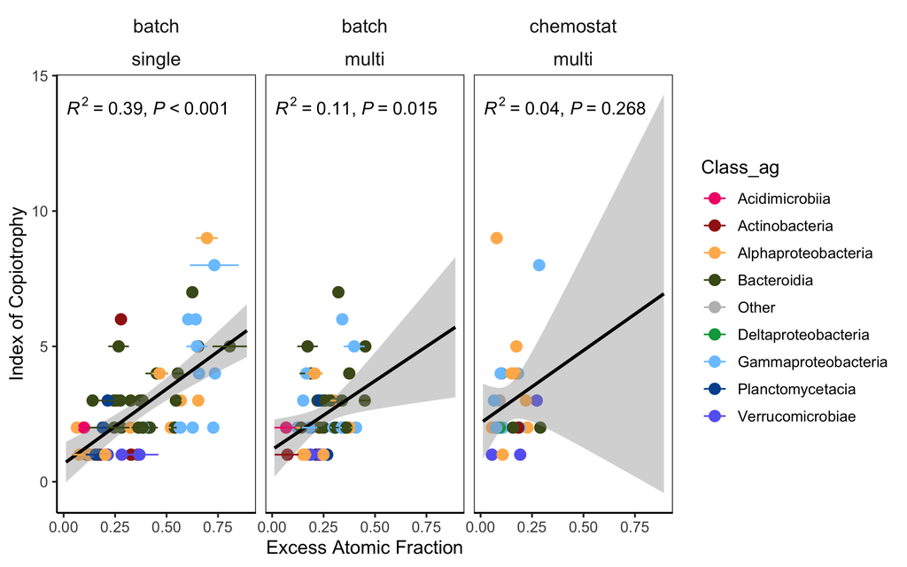

```r
ggplot(incorp_only, aes(x=observed_EAF, y=copy_number, color=Class_ag)) +
  #geom_point(size=as.numeric(incorp_only$copy_number)*0.7, alpha=0.8) +
  geom_point(size=3) +
  geom_smooth(aes(group = 1), method = "lm", se = TRUE, col='black', fullrange=TRUE)  +
  facet_wrap(Culture ~ Substrate) +
  stat_poly_eq(aes(group = 1,
                   label = paste(after_stat(rr.label), after_stat(p.value.label), sep = "*\", \"*")),
               formula = y ~ x, colour = "black",
               label.x = "left", label.y = "top", size = 4) +
  theme_bw(base_size=12) +
      geom_errorbar(aes(xmin = lower, xmax = upper), width = 0) +
  xlab("Excess Atomic Fraction") +
  ylab("Index of Copiotrophy") +
  theme(axis.line = element_line(colour = "black"),
    panel.grid.major = element_blank(),
    strip.text = element_text(size = 12),
    strip.background = element_blank(),
    panel.grid.minor = element_blank()) +
    scale_color_manual(values=custom_colors_class)
```

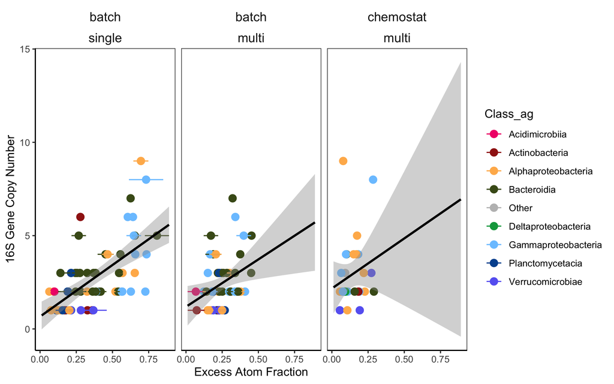

```r
ggplot(incorp_only, aes(x=A, y=copy_number, color=Class_ag)) +
  #geom_point(size=as.numeric(incorp_only$copy_number)*0.7, alpha=0.8) +
  geom_point(size=3) +
      geom_errorbar(aes(xmin = lower, xmax = upper), width = 0) +

  geom_smooth(aes(group = 1), method = "lm", se = TRUE, col='black',fullrange=TRUE)  +
  facet_wrap(Culture ~ Substrate) +
  theme_bw() +
  xlab("Excess Atom Fraction") +
  ylab("16S Gene Copy Number") +
  theme(axis.line = element_line(colour = "black"),
    panel.grid.major = element_blank(),
    strip.text = element_text(size = 12),
    strip.background = element_blank(),
    panel.grid.minor = element_blank()) +
    scale_color_manual(values=custom_colors_class)
```

```r
plot_16s=ggplot(incorp_only, aes(x=A, y=copy_number, color=Class_ag)) +
  #geom_point(size=as.numeric(incorp_only$copy_number)*0.7, alpha=0.8) +
  geom_point(size=3) +
  geom_smooth(aes(group = 1), method = "lm", se = TRUE, col='black',fullrange=TRUE)  +
  facet_wrap(Culture ~ Substrate) +
    geom_errorbar(aes(xmin = lower, xmax = upper), width = 0) +
  theme_bw(base_size=12) +
  xlab("Excess Atom Fraction") +
  ylab("16S Gene Copy Number") +
  theme(axis.line = element_line(colour = "black"),
    panel.grid.major = element_blank(),
    strip.text = element_text(size = 12),
    strip.background = element_blank(),
    panel.grid.minor = element_blank(), legend.position='none') +
    scale_color_manual(values=custom_colors_class)
```

### stats generated from here

```r
library(dplyr)
df=glucose_A
df2 <- df |>
  mutate(Copy_Number = as.numeric(as.character(Copy_Number)))

fit <- lm(Copy_Number ~ observed_EAF, data = df2)
summary(fit)
```

```
##
## Call:
## lm(formula = Copy_Number ~ observed_EAF, data = df2)
##
## Residuals:
##     Min      1Q  Median      3Q     Max
## -2.6802 -0.8203 -0.3096  0.7748  4.4898
##
## Coefficients:
##              Estimate Std. Error t value Pr(>|t|)
## (Intercept)    0.6620     0.3820   1.733   0.0881 .
## observed_EAF   5.5269     0.8858   6.239 4.61e-08 ***
## ---
## Signif. codes:  0 '***' 0.001 '**' 0.01 '*' 0.05 '.' 0.1 ' ' 1
##
## Residual standard error: 1.434 on 61 degrees of freedom
## Multiple R-squared:  0.3896, Adjusted R-squared:  0.3796
## F-statistic: 38.93 on 1 and 61 DF,  p-value: 4.611e-08
```

```r
gplot_glucose_A=ggplot(df2, aes(x = observed_EAF, y = Copy_Number)) +
  geom_errorbar(aes(xmin = lower, xmax = upper), width = 0) +
  geom_point() +
  geom_smooth(method = "lm", formula = y ~ x) +
  theme_bw()  +
  labs(title = "Batch Glucose", x='Excess Atom Fraction', y= '16S Gene Copy Number') +
  theme(axis.line = element_line(colour = "black"),
    panel.grid.major = element_blank(),
    panel.grid.minor = element_blank())


df=five_batch_A
df2 <- df |>
  mutate(Copy_Number = as.numeric(as.character(Copy_Number)))

fit <- lm(Copy_Number ~ observed_EAF, data = df2)
summary(fit)
```

```
##
## Call:
## lm(formula = Copy_Number ~ observed_EAF, data = df2)
##
## Residuals:
##     Min      1Q  Median      3Q     Max
## -1.5451 -1.0066 -0.3194  0.5330  4.1788
##
## Coefficients:
##              Estimate Std. Error t value Pr(>|t|)
## (Intercept)    1.1856     0.5486   2.161   0.0356 *
## observed_EAF   5.0807     2.0137   2.523   0.0149 *
## ---
## Signif. codes:  0 '***' 0.001 '**' 0.01 '*' 0.05 '.' 0.1 ' ' 1
##
## Residual standard error: 1.308 on 49 degrees of freedom
## Multiple R-squared:  0.115,  Adjusted R-squared:  0.09691
## F-statistic: 6.366 on 1 and 49 DF,  p-value: 0.01493
```

```r
gplot_batch_A=ggplot(df2, aes(x = observed_EAF, y = Copy_Number)) +
  geom_errorbar(aes(xmin = lower, xmax = upper), width = 0) +
  geom_point() +
  geom_smooth(method = "lm", formula = y ~ x) +
  theme_bw()  +
  labs(title = "Batch Five-Carbon", x='Excess Atom Fraction', y= '16S Gene Copy Number') +
  theme(axis.line = element_line(colour = "black"),
    panel.grid.major = element_blank(),
    panel.grid.minor = element_blank())



df=five_chemo_A
df2 <- df |>
  mutate(Copy_Number = as.numeric(as.character(Copy_Number)))

fit <- lm(Copy_Number ~ observed_EAF, data = df2)
summary(fit)
```

```
##
## Call:
## lm(formula = Copy_Number ~ observed_EAF, data = df2)
##
## Residuals:
##     Min      1Q  Median      3Q     Max
## -2.2006 -0.9471 -0.5741  0.7642  6.4126
##
## Coefficients:
##              Estimate Std. Error t value Pr(>|t|)
## (Intercept)    2.1681     0.7274   2.980  0.00589 **
## observed_EAF   5.3647     4.7446   1.131  0.26778
## ---
## Signif. codes:  0 '***' 0.001 '**' 0.01 '*' 0.05 '.' 0.1 ' ' 1
##
## Residual standard error: 1.817 on 28 degrees of freedom
## Multiple R-squared:  0.04367,    Adjusted R-squared:  0.00951
## F-statistic: 1.278 on 1 and 28 DF,  p-value: 0.2678
```

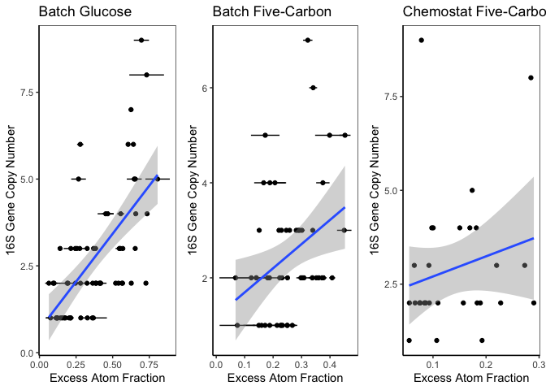

```r
gplot_chemo_A=ggplot(df2, aes(x = observed_EAF, y = Copy_Number)) +
  geom_errorbar(aes(xmin = lower, xmax = upper), width = 0) +
  geom_point() +
  geom_smooth(method = "lm", formula = y ~ x) +
  theme_bw()  +
  labs(title = "Chemostat Five-Carbon", x='Excess Atom Fraction', y= '16S Gene Copy Number') +
  theme(axis.line = element_line(colour = "black"),
    panel.grid.major = element_blank(),
    panel.grid.minor = element_blank())

cowplot::plot_grid(gplot_glucose_A, gplot_batch_A, gplot_chemo_A, ncol=3)
```

## Figure 3 b

```r
ioc_data=read.csv("/Users/oliviaahern/Documents/GitHub/Sip_CopyNumber/datafiles/gtdb_r220_ioc_25june26.csv",header=T)

incorp1=asv_results_filt_tax
incorp1 <- incorp1 |>
  dplyr::mutate(
    substrate = ifelse(grepl("glucose", treatment), "single", "multi"),
    culture   = ifelse(grepl("^Chemo", treatment), "chemostat", "batch")
  )

dplyr::count(incorp1, treatment, substrate, culture)
```

```
##       treatment substrate   culture  n
## 1  Chemo_carbon     multi chemostat 30
## 2  batch_carbon     multi     batch 51
## 3 batch_glucose    single     batch 63
```

```r
incorp_w_ioc=merge(incorp1, ioc_data, by='Strain')

custom_colors_class=c("Acidimicrobiia" ="#f21277",
                      "Actinobacteria" ="#a02016",
                      "Alphaproteobacteria" ="#ffb659",
                      "Bacteroidia" = "#48591c",
                      "Chloroflexia"='gray',
                      "Deltaproteobacteria" ="#01a34a",
                      "Gammaproteobacteria" ="#7bc6ff",
                      "OM190" = 'gray',
                      "Planctomycetacia" ="#00539e",
                      "Rhodothermia"='gray',
                      "Thermoleophilia" = 'gray',
                      "vadinHA49" = "gray",
                      "Verrucomicrobiae" ="#6868f2")
incorp_w_ioc$Class_ag=incorp_w_ioc$Class
incorp_w_ioc$Class_ag=as.factor(incorp_w_ioc$Class_ag)
levels(incorp_w_ioc$Class_ag) = c("Acidimicrobiia","Actinobacteria","Alphaproteobacteria","Bacteroidia","Deltaproteobacteria","Gammaproteobacteria","Planctomycetacia","Verrucomicrobiae")
custom_colors_class=c("Acidimicrobiia" ="#f21277",
                      "Actinobacteria" ="#a02016",
                      "Alphaproteobacteria" ="#ffb659",
                      "Bacteroidia" = "#48591c",
                                            "Other" = 'gray',

                      "Deltaproteobacteria" ="#01a34a",
                      "Gammaproteobacteria" ="#7bc6ff",
                      "Planctomycetacia" ="#00539e",
                      "Verrucomicrobiae" ="#6868f2")

desired_order=c("single", "multi")
incorp_w_ioc$substrate <- factor(incorp_w_ioc$substrate, levels = desired_order)





incorp_w_ioc |>
  dplyr::group_by(culture, substrate) |>
  dplyr::summarize(
    n  = dplyr::n(),
    r2 = summary(lm(IoC_genus_mean ~ observed_EAF))$r.squared,
    F  = summary(lm(IoC_genus_mean ~ observed_EAF))$fstatistic[1],
    p  = summary(lm(IoC_genus_mean ~ observed_EAF))$coefficients[2, 4],
    .groups = "drop"
  )
```

```
## # A tibble: 3 × 6
##   culture   substrate     n      r2       F        p
##   <chr>     <fct>     <int>   <dbl>   <dbl>    <dbl>
## 1 batch     single       45 0.261   15.2    0.000338
## 2 batch     multi        34 0.0329   1.09   0.304
## 3 chemostat multi        19 0.00302  0.0515 0.823
```

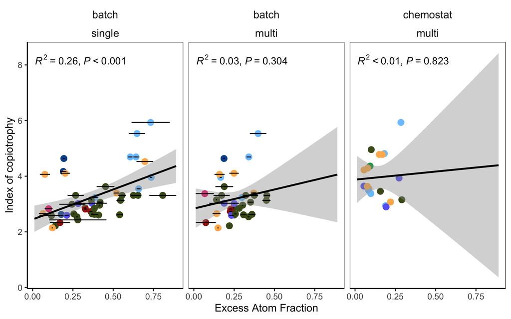

```r
plot_ioc=ggplot(incorp_w_ioc, aes(x=observed_EAF, y=IoC_genus_mean)) +
  geom_point(aes(color=Class_ag), size=3) +
  geom_smooth(method = "lm", se = TRUE, col='black',fullrange=TRUE)  +
  stat_poly_eq(formula = y ~ x,
               aes(label = paste(after_stat(rr.label), after_stat(p.value.label), sep = "*\", \"*")),
               label.x = "left", label.y = "top", size = 4) +
  facet_wrap(culture ~ substrate) +
  theme_bw(base_size=12) +
  xlab("Excess Atom Fraction") +
  ylab("Index of copiotrophy") +
  geom_errorbar(aes(xmin = lower, xmax = upper), width = 0) +
  theme(axis.line = element_line(colour = "black"),
    panel.grid.major = element_blank(),
    strip.text = element_text(size = 12),
    strip.background = element_blank(),
    panel.grid.minor = element_blank(), legend.position='none') +
    scale_color_manual(values=custom_colors_class)

plot_ioc
```

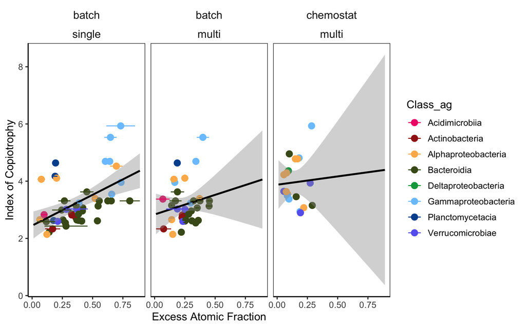

```r
formula = incorp_w_ioc$IoC_genus_mean ~ incorp_w_ioc$observed_EAF * incorp_w_ioc$culture * incorp_w_ioc$substrate

ggplot(incorp_w_ioc, aes(x=observed_EAF, y=IoC_genus_mean, color=Class_ag)) +
  #geom_point(size=as.numeric(incorp_only$copy_number)*0.7, alpha=0.8) +
  geom_point(size=3) +
  geom_smooth(method = "lm", se = TRUE, col='black',fullrange=TRUE)  +
  facet_wrap(culture ~ substrate) +
  theme_bw(base_size=12) +
      geom_errorbar(aes(xmin = lower, xmax = upper), width = 0) +
  xlab("Excess Atomic Fraction") +
  ylab("Index of Copiotrophy") +
  theme(axis.line = element_line(colour = "black"),
    panel.grid.major = element_blank(),
    strip.text = element_text(size = 12),
    strip.background = element_blank(),
    panel.grid.minor = element_blank()) +
    scale_color_manual(values=custom_colors_class)
```

```r
copio_plot=ggplot(incorp_w_ioc, aes(x=observed_EAF, y=IoC_genus_mean, color=Class_ag)) +
  #geom_point(size=as.numeric(incorp_only$copy_number)*0.7, alpha=0.8) +
  geom_point(size=3) +
  geom_smooth(method = "lm", se = TRUE, col='black',fullrange=TRUE)  +
  facet_wrap(culture ~ substrate) +
  theme_bw(base_size=12) +
        geom_errorbar(aes(xmin = lower, xmax = upper), width = 0) +
  xlab("Excess Atomic Fraction") +
  ylab("Index of Copiotrophy") +
  theme(axis.line = element_line(colour = "black"),
    panel.grid.major = element_blank(),
    strip.text = element_text(size = 12),
    strip.background = element_blank(),
    panel.grid.minor = element_blank(), legend.position = 'none') +
    scale_color_manual(values=custom_colors_class)
```

```r
library(ggh4x)
plot_16sa= plot_16s+ force_panelsizes(rows = unit(2.5, "in"),
                     cols = unit(2.5, "in"))
copio_plota=copio_plot+ force_panelsizes(rows = unit(2.5, "in"),
                     cols = unit(2.5, "in"))
quahog=cowplot::plot_grid(plot_16sa,copio_plota,
                   align='h',
                   axis='l',
                   byrow=TRUE,
                   nrow=2)
#ggsave('figure2_withioc.svg', plot=quahog, dpi=300)


copio_plot3=ggplot(incorp_w_ioc, aes(x=A, y=IoC_genus_mean, color=Class_ag)) +
  #geom_point(size=as.numeric(incorp_only$copy_number)*0.7, alpha=0.8) +
  geom_point(size=3) +
  geom_smooth(method = "lm", se = TRUE, col='black',fullrange=TRUE)  +
  facet_wrap(Culture ~ Substrate) +
  theme_bw(base_size=12) +
  xlab("Excess Atomic Fraction") +
  ylab("Index of Copiotrophy") +
  theme(axis.line = element_line(colour = "black"),
    panel.grid.major = element_blank(),
    strip.text = element_text(size = 12),
    strip.background = element_blank(),
    panel.grid.minor = element_blank(), legend.position = 'bottom') +
    scale_color_manual(values=custom_colors_class) + force_panelsizes(rows = unit(2.5, "in"),
                     cols = unit(2.5, "in"))
copio_plot3


ggsave('copioplot_legend.svg', plot=copio_plot3, dpi=300)

cowplot::plot_grid(copio_plot3,
                   align='h',
                   axis='l',
                   byrow=TRUE,
                   nrow=2)
```

### stats generated from here

```r
df2=subset(incorp_w_ioc, treatment=="batch_glucose")
fit <- lm(IoC_genus_mean ~ observed_EAF, data = df2)
summary(fit)
```

```
##
## Call:
## lm(formula = IoC_genus_mean ~ observed_EAF, data = df2)
##
## Residuals:
##     Min      1Q  Median      3Q     Max
## -0.9960 -0.4896 -0.2822  0.1697  1.9089
##
## Coefficients:
##              Estimate Std. Error t value Pr(>|t|)
## (Intercept)    2.4458     0.2400  10.192 4.83e-13 ***
## observed_EAF   2.1558     0.5534   3.895 0.000338 ***
## ---
## Signif. codes:  0 '***' 0.001 '**' 0.01 '*' 0.05 '.' 0.1 ' ' 1
##
## Residual standard error: 0.7446 on 43 degrees of freedom
## Multiple R-squared:  0.2608, Adjusted R-squared:  0.2436
## F-statistic: 15.17 on 1 and 43 DF,  p-value: 0.0003376
```

```r
gplot_glucose_A=ggplot(df2, aes(x = observed_EAF, y = IoC_genus_mean)) +
  geom_errorbar(aes(xmin = lower, xmax = upper), width = 0, orientation = "y") +
  geom_point() +
  geom_smooth(method = "lm", formula = y ~ x) +
  theme_bw()  +
  labs(title = "Batch Glucose", x= 'Excess Atom Fraction', y='Index of Copiotrophy') +
  theme(axis.line = element_line(colour = "black"),
    panel.grid.major = element_blank(),
    panel.grid.minor = element_blank())


df2=subset(incorp_w_ioc, treatment=="batch_carbon")
fit <- lm(IoC_genus_mean ~ observed_EAF, data = df2)
summary(fit)
```

```
##
## Call:
## lm(formula = IoC_genus_mean ~ observed_EAF, data = df2)
##
## Residuals:
##     Min      1Q  Median      3Q     Max
## -0.9223 -0.5137 -0.2084  0.2098  2.1488
##
## Coefficients:
##              Estimate Std. Error t value Pr(>|t|)
## (Intercept)    2.8362     0.3616   7.843 6.01e-09 ***
## observed_EAF   1.3723     1.3148   1.044    0.304
## ---
## Signif. codes:  0 '***' 0.001 '**' 0.01 '*' 0.05 '.' 0.1 ' ' 1
##
## Residual standard error: 0.7416 on 32 degrees of freedom
## Multiple R-squared:  0.03292,    Adjusted R-squared:  0.002701
## F-statistic: 1.089 on 1 and 32 DF,  p-value: 0.3044
```

```r
gplot_batch_A=ggplot(df2, aes(x = observed_EAF, y = IoC_genus_mean)) +
  geom_errorbar(aes(xmin = lower, xmax = upper), width = 0, orientation = "y") +
  geom_point() +
  geom_smooth(method = "lm", formula = y ~ x) +
  theme_bw()  +
  labs(title = "Batch Five-Carbon", x= 'Excess Atom Fraction', y='Index of Copiotrophy') +
  theme(axis.line = element_line(colour = "black"),
    panel.grid.major = element_blank(),
    panel.grid.minor = element_blank())



df2=subset(incorp_w_ioc, treatment=="Chemo_carbon")
fit <- lm(IoC_genus_mean ~ observed_EAF, data = df2)
summary(fit)
```

```
##
## Call:
## lm(formula = IoC_genus_mean ~ observed_EAF, data = df2)
##
## Residuals:
##     Min      1Q  Median      3Q     Max
## -1.0916 -0.5333 -0.2639  0.6195  1.8917
##
## Coefficients:
##              Estimate Std. Error t value Pr(>|t|)
## (Intercept)    3.8759     0.4283   9.049 6.56e-08 ***
## observed_EAF   0.5815     2.5631   0.227    0.823
## ---
## Signif. codes:  0 '***' 0.001 '**' 0.01 '*' 0.05 '.' 0.1 ' ' 1
##
## Residual standard error: 0.8422 on 17 degrees of freedom
## Multiple R-squared:  0.003019,   Adjusted R-squared:  -0.05563
## F-statistic: 0.05148 on 1 and 17 DF,  p-value: 0.8232
```

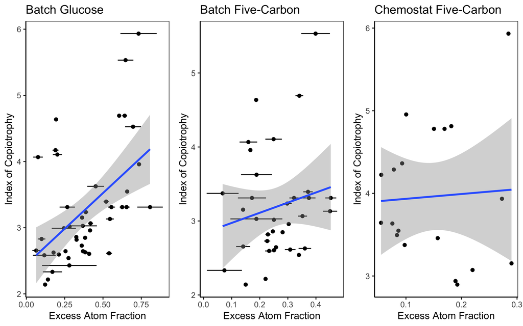

```r
gplot_chemo_A=ggplot(df2, aes(x = observed_EAF, y = IoC_genus_mean)) +
  geom_errorbar(aes(xmin = lower, xmax = upper), width = 0, orientation = "y") +
  geom_point() +
  geom_smooth(method = "lm", formula = y ~ x) +
  theme_bw()  +
  labs(title = "Chemostat Five-Carbon", x= 'Excess Atom Fraction', y='Index of Copiotrophy') +
  theme(axis.line = element_line(colour = "black"),
    panel.grid.major = element_blank(),
    panel.grid.minor = element_blank())

cowplot::plot_grid(gplot_glucose_A, gplot_batch_A, gplot_chemo_A, ncol=3)
```

## Figure 4

```r
multi=subset(incorp_only, Substrate=="multi" & Culture=="batch")
single=subset(incorp_only, Substrate=="single" & Culture=="batch")

# ---- shared batch incorporators, with each treatment's CI ----
both <- merge(
  single[, c("feature_id", "A", "lower", "upper", "Class", "copy_number")],
  multi[,  c("feature_id", "A", "lower", "upper")],
  by = "feature_id", suffixes = c("_single", "_multi")
)
both$Single <- both$A_single
both$Multi  <- both$A_multi

custom_colors_class=c("Acidimicrobiia" ="#f21277",
                      "Actinobacteria" ="#a02016",
                      "Alphaproteobacteria" ="#ffb659",
                      "Bacteroidia" = "#48591c",
                      "Other" = 'gray',
                      "Deltaproteobacteria" ="#01a34a",
                      "Gammaproteobacteria" ="#7bc6ff",
                      "Planctomycetacia" ="#00539e",
                      "Verrucomicrobiae" ="#6868f2")

both$Class_ag = ifelse(both$Class %in% names(custom_colors_class), as.character(both$Class), "Other")
both$Class_ag = factor(both$Class_ag, levels = names(custom_colors_class))

# ---- regression stats for the annotation ----
summary(lm(Single ~ Multi, data = both))
```

```
##
## Call:
## lm(formula = Single ~ Multi, data = both)
##
## Residuals:
##      Min       1Q   Median       3Q      Max
## -0.22377 -0.10893  0.00129  0.09399  0.49310
##
## Coefficients:
##             Estimate Std. Error t value Pr(>|t|)
## (Intercept)  0.01786    0.06831   0.261    0.795
## Multi        1.34593    0.24315   5.535 1.52e-06 ***
## ---
## Signif. codes:  0 '***' 0.001 '**' 0.01 '*' 0.05 '.' 0.1 ' ' 1
##
## Residual standard error: 0.143 on 45 degrees of freedom
## Multiple R-squared:  0.4051, Adjusted R-squared:  0.3919
## F-statistic: 30.64 on 1 and 45 DF,  p-value: 1.519e-06
```

```r
nrow(both)
```

```
## [1] 47
```

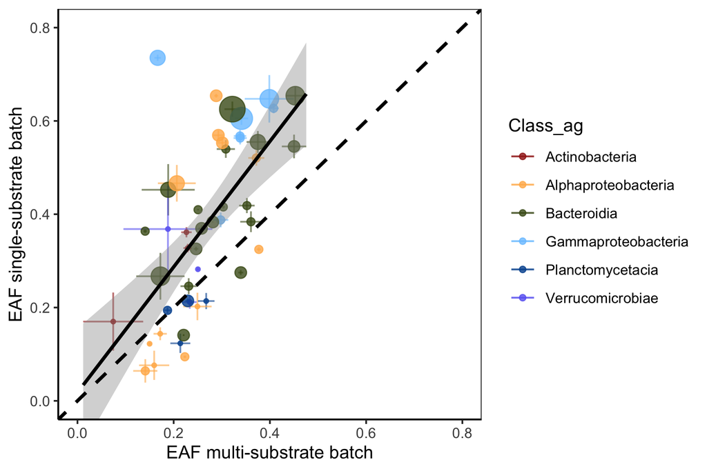

```r
ggplot(both, aes(x=as.numeric(A_multi), y=as.numeric(A_single),  color=Class_ag)) +
  geom_errorbar(aes(ymin = lower_single, ymax = upper_single), width = 0, alpha = 0.6) +
  geom_errorbar(aes(xmin = lower_multi,  xmax = upper_multi),  width = 0, alpha = 0.6) +
  geom_point(size=as.numeric(both$copy_number), alpha=0.8) +
  theme_bw() +
  coord_cartesian(xlim = c(0, 0.8), ylim = c(0, 0.8)) +
  theme(axis.line = element_line(colour = "black"),
    panel.grid.major = element_blank(),
    panel.grid.minor = element_blank()) +
    geom_smooth(aes(group = 1), method = "lm", se = TRUE, col='black',fullrange=TRUE) +
    geom_abline(intercept = 0, slope = 1, color = "black", linetype = "dashed", linewidth = 1) +
  xlab("EAF multi-substrate batch") +
  ylab("EAF single-substrate batch") +
#  annotate("text", label="R2 = 0.30 \n F = 25.38 \n p = 5.4 e-6", x=0.6, y=0.4) +
  scale_color_manual(values=custom_colors_class)
```

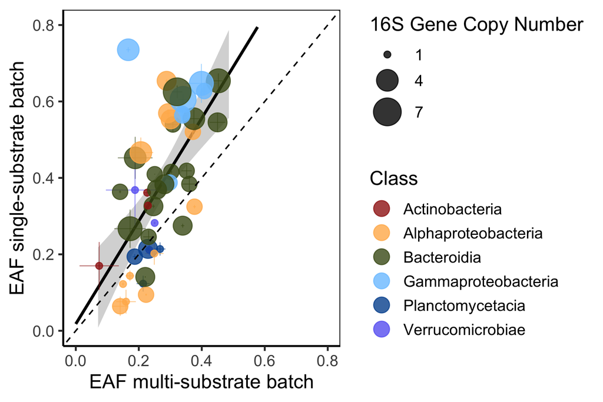

```r
# new
fit4 <- summary(lm(Single ~ Multi, data = both))
lab4 <- paste0("R\u00b2 = ", sprintf("%.2f", fit4$r.squared),
               "\nF = ", sprintf("%.2f", fit4$fstatistic[1]),
              "\np = ", format(signif(coef(fit4)[2, 4], 2), scientific = TRUE))
library(dplyr)
both <- both %>%
  mutate(copy_number = as.numeric(as.character(copy_number)))

new2=ggplot(both, aes(x=as.numeric(Multi), y=as.numeric(Single),  color=Class)) +
  geom_smooth(aes(group = 1), method = "lm", se = TRUE, col='black',fullrange=TRUE,linewidth=1) +
  geom_errorbar(aes(ymin = lower_single, ymax = upper_single), width = 0, alpha = 0.6, linewidth = 0.3) +
  geom_errorbar(aes(xmin = lower_multi,  xmax = upper_multi),  width = 0, alpha = 0.6, linewidth = 0.3) +
  geom_point(aes(size=as.numeric(copy_number)), alpha=0.8, show.legend=TRUE) +
  theme_bw(base_size = 14) +
  scale_size(range = c(2, 9), breaks = c(1, 4, 7)) +
  ylim(c(0,0.8)) + xlim(c(0,0.8))  +
  theme(axis.line = element_line(colour = "black"),
    panel.grid.major = element_blank(),
    panel.grid.minor = element_blank(),
    strip.text = element_text(size = 12)) +
  geom_abline(intercept = 0, slope = 1, color = "black", linetype = "dashed") +
  xlab("EAF multi-substrate batch") +
  ylab("EAF single-substrate batch") +
  labs(size = "16S Gene Copy Number") +
# annotate("text", label = lab4, x = 0.6, y = 0.2, hjust = 0, size = 4.5) +
  scale_color_manual(values=custom_colors_class) +
  guides(color = guide_legend(override.aes = list(size = 5, linetype = 0)))

new2
```

```r
#ggsave(filename = 'figure4.svg', new2, dpi=300,height=3.7, width=6, units='in')
```

### reviewer dilution question

```r
both <- both %>%
  mutate(ratio = as.numeric(Multi) / as.numeric(Single))

median(both$ratio)
```

```
## [1] 0.7139737
```

```r
multi=subset(incorp_only, Substrate=="multi" & Culture=="batch")
single=subset(incorp_only, Substrate=="single" & Culture=="batch")

both <- merge(
  single[, c("feature_id", "A", "lower", "upper", "Class", "copy_number")],
  multi[,  c("feature_id", "A", "lower", "upper")],
  by = "feature_id", suffixes = c("_single", "_multi")
)
both$Single <- both$A_single
both$Multi  <- both$A_multi

custom_colors_class=c("Acidimicrobiia" ="#f21277",
                      "Actinobacteria" ="#a02016",
                      "Alphaproteobacteria" ="#ffb659",
                      "Bacteroidia" = "#48591c",
                      "Other" = 'gray',
                      "Deltaproteobacteria" ="#01a34a",
                      "Gammaproteobacteria" ="#7bc6ff",
                      "Planctomycetacia" ="#00539e",
                      "Verrucomicrobiae" ="#6868f2")

both$Class_ag = ifelse(both$Class %in% names(custom_colors_class), as.character(both$Class), "Other")
both$Class_ag = factor(both$Class_ag, levels = names(custom_colors_class))

# ---- regression stats for the annotation ----
summary(lm(Single ~ Multi, data = both))
```

```
##
## Call:
## lm(formula = Single ~ Multi, data = both)
##
## Residuals:
##      Min       1Q   Median       3Q      Max
## -0.22377 -0.10893  0.00129  0.09399  0.49310
##
## Coefficients:
##             Estimate Std. Error t value Pr(>|t|)
## (Intercept)  0.01786    0.06831   0.261    0.795
## Multi        1.34593    0.24315   5.535 1.52e-06 ***
## ---
## Signif. codes:  0 '***' 0.001 '**' 0.01 '*' 0.05 '.' 0.1 ' ' 1
##
## Residual standard error: 0.143 on 45 degrees of freedom
## Multiple R-squared:  0.4051, Adjusted R-squared:  0.3919
## F-statistic: 30.64 on 1 and 45 DF,  p-value: 1.519e-06
```

```r
nrow(both)
```

```
## [1] 47
```

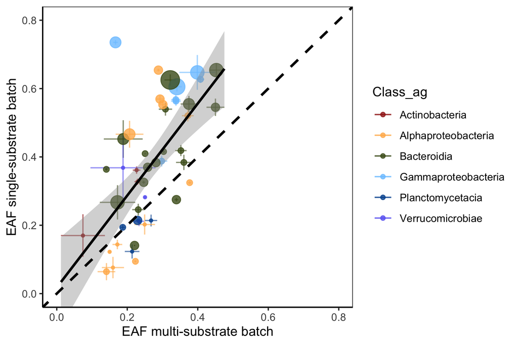

```r
ggplot(both, aes(x=as.numeric(A_multi), y=as.numeric(A_single),  color=Class_ag)) +
  geom_errorbar(aes(ymin = lower_single, ymax = upper_single), width = 0, alpha = 0.6) +
  geom_errorbar(aes(xmin = lower_multi,  xmax = upper_multi),  width = 0, alpha = 0.6) +
  geom_point(size=as.numeric(both$copy_number), alpha=0.8) +
  theme_bw() +
  coord_cartesian(xlim = c(0, 0.8), ylim = c(0, 0.8)) +
  theme(axis.line = element_line(colour = "black"),
    panel.grid.major = element_blank(),
    panel.grid.minor = element_blank()) +
    geom_smooth(aes(group = 1), method = "lm", se = TRUE, col='black',fullrange=TRUE) +
    geom_abline(intercept = 0, slope = 1, color = "black", linetype = "dashed", linewidth = 1) +
  xlab("EAF multi-substrate batch") +
  ylab("EAF single-substrate batch") +
#  annotate("text", label="R2 = 0.30 \n F = 25.38 \n p = 5.4 e-6", x=0.6, y=0.4) +
  scale_color_manual(values=custom_colors_class)
```

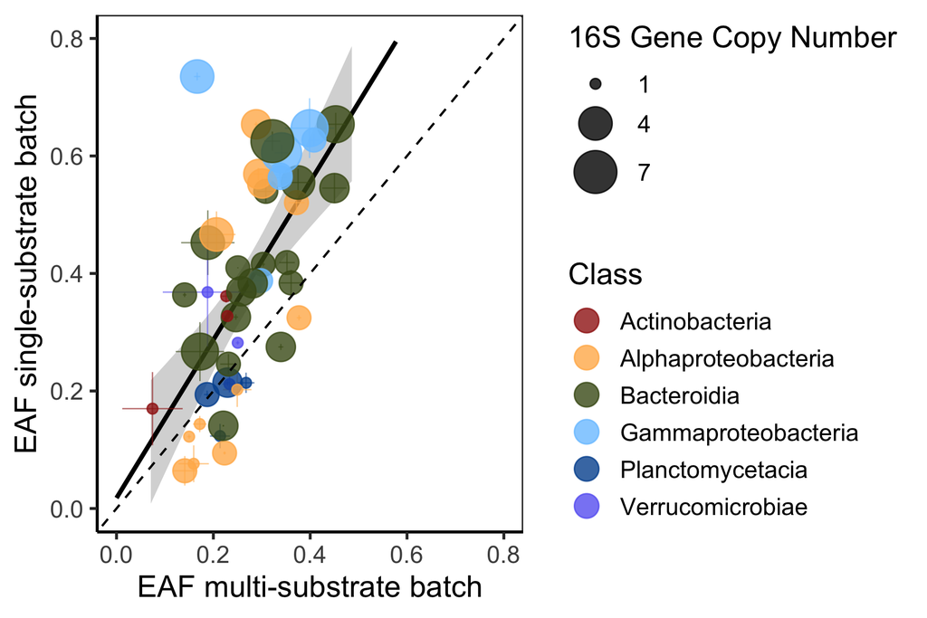

```r
# new
fit4 <- summary(lm(Single ~ Multi, data = both))
lab4 <- paste0("R\u00b2 = ", sprintf("%.2f", fit4$r.squared),
               "\nF = ", sprintf("%.2f", fit4$fstatistic[1]),
              "\np = ", format(signif(coef(fit4)[2, 4], 2), scientific = TRUE))
library(dplyr)
both <- both %>%
  mutate(copy_number = as.numeric(as.character(copy_number)))

new2=ggplot(both, aes(x=as.numeric(Multi), y=as.numeric(Single),  color=Class)) +
  geom_smooth(aes(group = 1), method = "lm", se = TRUE, col='black',fullrange=TRUE,linewidth=1) +
  geom_errorbar(aes(ymin = lower_single, ymax = upper_single), width = 0, alpha = 0.6, linewidth = 0.3) +
  geom_errorbar(aes(xmin = lower_multi,  xmax = upper_multi),  width = 0, alpha = 0.6, linewidth = 0.3) +
  geom_point(aes(size=as.numeric(copy_number)), alpha=0.8, show.legend=TRUE) +
  theme_bw(base_size = 14) +
  scale_size(range = c(2, 9), breaks = c(1, 4, 7)) +
  ylim(c(0,0.8)) + xlim(c(0,0.8))  +
  theme(axis.line = element_line(colour = "black"),
    panel.grid.major = element_blank(),
    panel.grid.minor = element_blank(),
    strip.text = element_text(size = 12)) +
  geom_abline(intercept = 0, slope = 1, color = "black", linetype = "dashed") +
  xlab("EAF multi-substrate batch") +
  ylab("EAF single-substrate batch") +
  labs(size = "16S Gene Copy Number") +
# annotate("text", label = lab4, x = 0.6, y = 0.2, hjust = 0, size = 4.5) +
  scale_color_manual(values=custom_colors_class) +
  guides(color = guide_legend(override.aes = list(size = 5, linetype = 0)))

new2
```

```r
#ggsave(filename = 'figure4.svg', new2, dpi=300,height=3.7, width=6, units='in')
```

### some stats

##### eaf between treatments

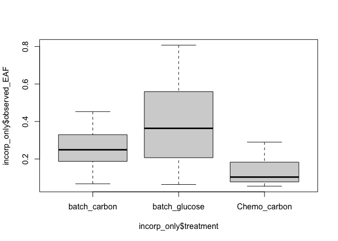

```r
a=aov(incorp_only$observed_EAF~incorp_only$treatment)
boxplot(incorp_only$observed_EAF~incorp_only$treatment)
```

```r
summary(a)
```

```
##                        Df Sum Sq Mean Sq F value   Pr(>F)
## incorp_only$treatment   2  1.271  0.6353   28.09 5.39e-11 ***
## Residuals             141  3.189  0.0226
## ---
## Signif. codes:  0 '***' 0.001 '**' 0.01 '*' 0.05 '.' 0.1 ' ' 1
```

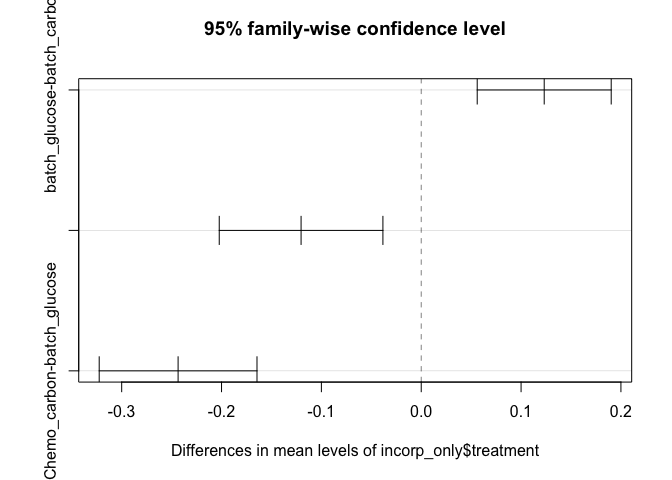

```r
tuk=TukeyHSD(a)
plot(tuk)
```

```r
aggregate(observed_EAF ~ treatment, data = incorp_only, FUN = mean)
```

```
##       treatment observed_EAF
## 1  batch_carbon    0.2567717
## 2 batch_glucose    0.3799381
## 3  Chemo_carbon    0.1364361
```

```r
aggregate(observed_EAF ~ treatment, data = incorp_only, FUN = sd)
```

```
##       treatment observed_EAF
## 1  batch_carbon   0.09186945
## 2 batch_glucose   0.20556485
## 3  Chemo_carbon   0.07112750
```

##### gene copy number between treatments

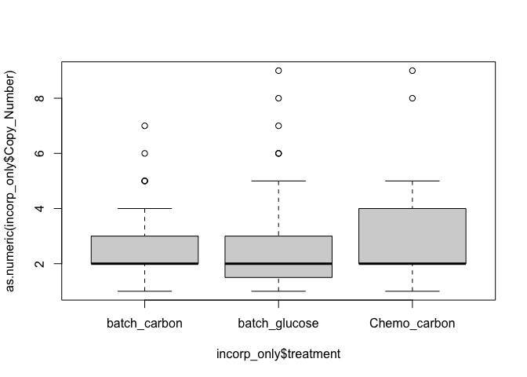

```r
a=aov(as.numeric(incorp_only$Copy_Number)~incorp_only$treatment)
boxplot(as.numeric(incorp_only$Copy_Number)~incorp_only$treatment)
```

```r
summary(a)
```

```
##                        Df Sum Sq Mean Sq F value Pr(>F)
## incorp_only$treatment   2    3.7   1.841   0.654  0.522
## Residuals             141  396.9   2.815
```

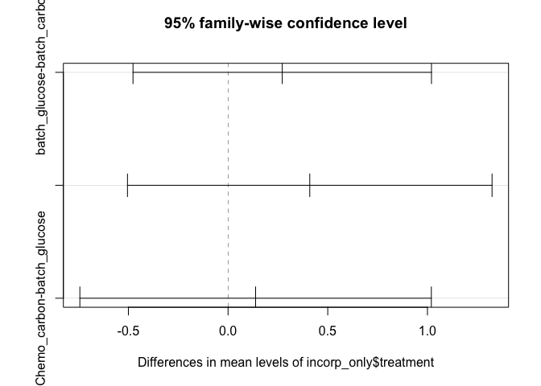

```r
tuk=TukeyHSD(a)
plot(tuk)
```

```r
aggregate(as.numeric(Copy_Number) ~ treatment, data = incorp_only, FUN = mean)
```

```
##       treatment as.numeric(Copy_Number)
## 1  batch_carbon                2.490196
## 2 batch_glucose                2.761905
## 3  Chemo_carbon                2.900000
```

```r
aggregate(as.numeric(Copy_Number) ~ treatment, data = incorp_only, FUN = sd)
```

```
##       treatment as.numeric(Copy_Number)
## 1  batch_carbon                1.376554
## 2 batch_glucose                1.820265
## 3  Chemo_carbon                1.826057
```

##### ioc

```r
summary(as.factor(incorp_w_ioc$treatment))
```

```
##  batch_carbon batch_glucose  Chemo_carbon
##            34            45            19
```

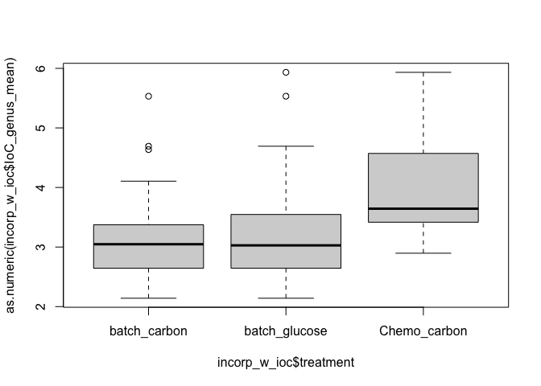

```r
a=aov(as.numeric(incorp_w_ioc$IoC_genus_mean)~incorp_w_ioc$treatment)
boxplot(as.numeric(incorp_w_ioc$IoC_genus_mean)~incorp_w_ioc$treatment)
```

```r
summary(a)
```

```
##                        Df Sum Sq Mean Sq F value  Pr(>F)
## incorp_w_ioc$treatment  2   8.18   4.091   6.214 0.00291 **
## Residuals              95  62.55   0.658
## ---
## Signif. codes:  0 '***' 0.001 '**' 0.01 '*' 0.05 '.' 0.1 ' ' 1
```

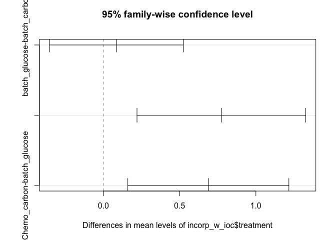

```r
tuk=TukeyHSD(a)
plot(tuk)
```

```r
aggregate(as.numeric(IoC_genus_mean) ~ treatment, data = incorp_w_ioc, FUN = mean)
```

```
##       treatment as.numeric(IoC_genus_mean)
## 1  batch_carbon                   3.189558
## 2 batch_glucose                   3.274581
## 3  Chemo_carbon                   3.962589
```

```r
aggregate(as.numeric(IoC_genus_mean) ~ treatment, data = incorp_w_ioc, FUN = sd)
```

```
##       treatment as.numeric(IoC_genus_mean)
## 1  batch_carbon                  0.7426471
## 2 batch_glucose                  0.8561274
## 3  Chemo_carbon                  0.8197330
```

### SI Figure 2 - gc content and copy number

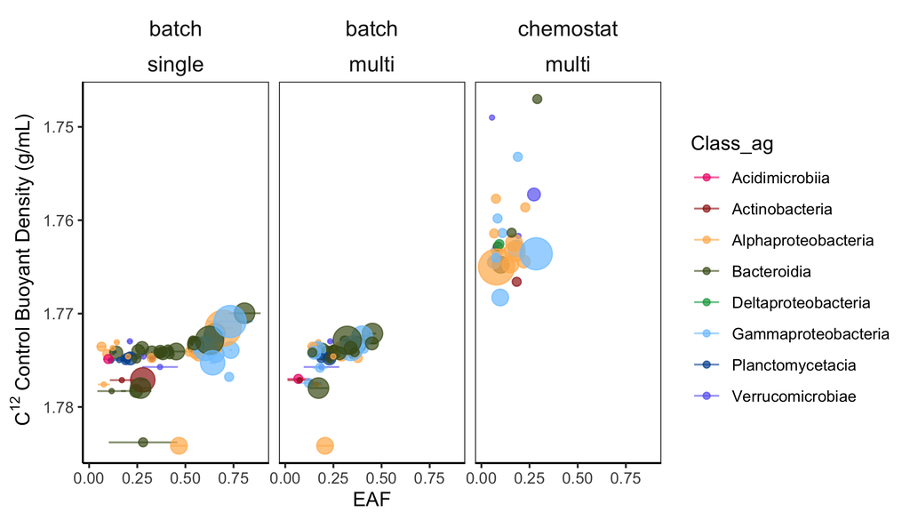

```r
#dim(incorp_only)
#incorp_only$Class
incorp_only2=incorp_only
## add
library(dplyr)
incorp_only2 <- incorp_only2 %>%
  left_join(shift_df %>% dplyr::select(treatment, feature_id, W_unlab),
            by = c("treatment", "feature_id"))

incorp_only2$Class_ag=incorp_only2$Class
incorp_only2$Class_ag=as.factor(incorp_only2$Class_ag)

custom_colors_class=c("Acidimicrobiia" ="#f21277",
                      "Actinobacteria" ="#a02016",
                      "Alphaproteobacteria" ="#ffb659",
                      "Bacteroidia" = "#48591c",
                                            "Other" = 'gray',

                      "Deltaproteobacteria" ="#01a34a",
                      "Gammaproteobacteria" ="#7bc6ff",
                      "Planctomycetacia" ="#00539e",
                      "Verrucomicrobiae" ="#6868f2")

desired_order=c("single", "multi")
incorp_only2$Substrate <- factor(incorp_only2$Substrate, levels = desired_order)


ggplot(incorp_only2, aes(x=A, y=W_unlab, fill=Class_ag, color=Class_ag)) +
  geom_errorbar(aes(xmin = lower,  xmax = upper),  width = 0, alpha = 0.6) +
   geom_point(size=as.numeric(incorp_only2$copy_number),alpha=0.7) +
  #geom_point(size=3) +
  facet_wrap(Culture ~ Substrate) +
  theme_bw() +
  theme(legend.position='right') +
  scale_fill_manual(values=custom_colors_class) +
  scale_color_manual(values=custom_colors_class) +
      scale_y_reverse() +
  xlab("EAF") +
  ylab(expression(" "*C^12*" Control Buoyant Density (g/mL)")) +
  theme(axis.line = element_line(colour = "black"),
    panel.grid.major = element_blank(),
    strip.text = element_text(size = 12),
    strip.background = element_blank(),
    panel.grid.minor = element_blank())
```

```r
# new
gplot_s2=ggplot(incorp_only2, aes(x=A, y=W_unlab,  fill=Class_ag, color= Class_ag,size=copy_number)) +
geom_errorbar(aes(xmin = lower,  xmax = upper), linewidth=1,  alpha = 0.6) +
   geom_point(alpha=0.8,show.legend=TRUE)+
    theme_bw(base_size = 12) +

  facet_wrap(Culture ~ Substrate) +
  theme_bw() +
  theme(legend.position='right') +
  scale_fill_manual(values=custom_colors_class) +
  scale_color_manual(values=custom_colors_class) +
      scale_y_reverse() +
  xlab("EAF") +
  ylab(expression(" "*C^12*" Control Buoyant Density (g/mL)")) +
  theme(axis.line = element_line(colour = "black"),
    panel.grid.major = element_blank(),
    strip.text = element_text(size = 12),
    strip.background = element_blank(),
    panel.grid.minor = element_blank()) + scale_color_manual(values=custom_colors_class) + guides(color = guide_legend(override.aes = list(size = 4)))

#ggsave(plot=gplot_s2, 'sifigure2.svg', dpi=300, height = 5, width=10.5)
```

### SI Figure 4 - EAF by genera

```r
library(dplyr)
library(ggplot2)


custom_colors_class=c("Acidimicrobiia" ="#f21277",
                      "Actinobacteria" ="#a02016",
                      "Alphaproteobacteria" ="#ffb659",
                      "Bacteroidia" = "#48591c",
                      "Other" = 'gray',
                      "Deltaproteobacteria" ="#01a34a",
                      "Gammaproteobacteria" ="#7bc6ff",
                      "Planctomycetacia" ="#00539e",
                      "Verrucomicrobiae" ="#6868f2")

incorp_only2$Class_ag = ifelse(incorp_only$Class %in% names(custom_colors_class), as.character(incorp_only2$Class), "Other")
incorp_only2$Class_ag = factor(incorp_only2$Class_ag, levels = names(custom_colors_class))


plot_df <- incorp_only2 %>%
  filter(!is.na(Genus), !Genus %in% c("", "uncultured", "uncultured bacterium", "Ambiguous_taxa")) %>%
  mutate(Genus_label = Genus,
         panel = factor(paste0(Substrate, "-substrate ", Culture),
                        levels = c("single-substrate batch",
                                   "multi-substrate batch",
                                   "multi-substrate chemostat")),
         Genus_label = reorder(Genus_label, observed_EAF, FUN = mean))

gplot_s3=ggplot(plot_df, aes(x = observed_EAF, y = Genus_label, fill=Class_ag)) +
  geom_vline(xintercept = 0, linetype = "dotted") +
  geom_errorbar(aes(xmin = lower, xmax = upper), width = 0, orientation = "y") +
  geom_point(shape = 21,  size = 2, alpha=0.7) +
  facet_grid(. ~ panel) +
  scale_fill_manual(values=custom_colors_class) +
  scale_x_continuous(breaks = c(0, 0.25, 0.5, 0.75)) +
  labs(x = expression("EAF"), y = NULL) +
  theme_bw(base_size = 12) +
  theme(strip.background = element_blank(),
        strip.text = element_text(size = 12),
        panel.grid.minor = element_blank(),
        axis.text.y = element_text(size = 8, face='italic'))


#ggsave('si_fig4.svg', plot=gplot_s3, height=6,width=12, dpi=300)
```